# ANCOVA in Reading Correct Words (1 Min) (Reading Correct Words (1 Min))

Geiser C. Challco geiser@alumni.usp.br

- Setting Initial Variables
- Descriptive Statistics of Initial Data
- ANCOVA and Pairwise for one factor: **grupo**
  - Without remove non-normal data
  - Computing ANCOVA and PairWise After removing non-normal data (OK)
    - Plots for ancova
    - Checking linearity assumption
    - Checking normality and homogeneity
- ANCOVA and Pairwise for two factors **grupo:Sexo**
  - Without remove non-normal data
  - Computing ANCOVA and PairWise After removing non-normal data (OK)
    - Plots for ancova
    - Checking linearity assumption
    - Checking normality and homogeneity
- ANCOVA and Pairwise for two factors **grupo:Zona**
  - Without remove non-normal data
  - Computing ANCOVA and PairWise After removing non-normal data (OK)
    - Plots for ancova
    - Checking linearity assumption
    - Checking normality and homogeneity
- ANCOVA and Pairwise for two factors **grupo:Cor.Raca**
  - Without remove non-normal data
  - Computing ANCOVA and PairWise After removing non-normal data (OK)
    - Plots for ancova
    - Checking linearity assumption
    - Checking normality and homogeneity
- ANCOVA and Pairwise for two factors **grupo:Serie**
  - Without remove non-normal data
  - Computing ANCOVA and PairWise After removing non-normal data (OK)
    - Plots for ancova
    - Checking linearity assumption
    - Checking normality and homogeneity
- ANCOVA and Pairwise for two factors **grupo:TFL.corretas.per.min.quintile**
  - Without remove non-normal data
  - Computing ANCOVA and PairWise After removing non-normal data (OK)
    - Plots for ancova
    - Checking linearity assumption
    - Checking normality and homogeneity
- Summary of Results
  - Descriptive Statistics
  - ANCOVA Table Comparison
  - PairWise Table Comparison
  - EMMS Table Comparison

**NOTE**:

- Teste ANCOVA para determinar se houve diferenças significativas no Reading Correct Words (1 Min) (medido usando pre- e pos-testes).
- ANCOVA test to determine whether there were significant differences in Reading Correct Words (1 Min) (measured using pre- and post-tests).

# Setting Initial Variables

```r
dv = "TFL.corretas.per.min"
dv.pos = "TFL.corretas.per.min.pos"
dv.pre = "TFL.corretas.per.min.pre"

fatores2 <- c("Sexo","Zona","Cor.Raca","Serie","TFL.corretas.per.min.quintile")
lfatores2 <- as.list(fatores2)
names(lfatores2) <- fatores2

fatores1 <- c("grupo", fatores2)
lfatores1 <- as.list(fatores1)
names(lfatores1) <- fatores1

lfatores <- c(lfatores1)

color <- list()
color[["prepost"]] = c("#ffee65","#f28e2B")
color[["grupo"]] = c("#bcbd22","#fd7f6f")
color[["Sexo"]] = c("#FF007F","#4D4DFF")
color[["Zona"]] = c("#AA00FF","#00CCCC")
color[["Cor.Raca"]] = c(
  "Parda"="#b97100","Indígena"="#9F262F",
  "Branca"="#87c498", "Preta"="#848283","Amarela"="#D6B91C"
)

level <- list()
level[["grupo"]] = c("Controle","Experimental")
level[["Sexo"]] = c("F","M")
level[["Zona"]] = c("Rural","Urbana")
level[["Cor.Raca"]] = c("Parda","Indígena","Branca", "Preta","Amarela")
level[["Serie"]] = c("6 ano","7 ano","8 ano","9 ano")

# ..

ymin <- 0
ymax <- 0

ymin.ci <- 0
ymax.ci <- 0


color[["grupo:Sexo"]] = c(
  "Controle:F"="#ff99cb", "Controle:M"="#b7b7ff",
  "Experimental:F"="#FF007F", "Experimental:M"="#4D4DFF",
  "Controle.F"="#ff99cb", "Controle.M"="#b7b7ff",
  "Experimental.F"="#FF007F", "Experimental.M"="#4D4DFF"
)
color[["grupo:Zona"]] = c(
  "Controle:Rural"="#b2efef","Controle:Urbana"="#e5b2ff",
  "Experimental:Rural"="#00CCCC", "Experimental:Urbana"="#AA00FF",
  "Controle.Rural"="#b2efef","Controle.Urbana"="#e5b2ff",
  "Experimental.Rural"="#00CCCC", "Experimental.Urbana"="#AA00FF"
)
color[["grupo:Cor.Raca"]] = c(
    "Controle:Parda"="#e3c699", "Experimental:Parda"="#b97100",
    "Controle:Indígena"="#e2bdc0", "Experimental:Indígena"="#9F262F",
    "Controle:Branca"="#c0e8cb", "Experimental:Branca"="#87c498",
    "Controle:Preta"="#dad9d9", "Experimental:Preta"="#848283",
    "Controle:Amarela"="#eee3a4", "Experimental:Amarela"="#D6B91C",

    "Controle.Parda"="#e3c699", "Experimental.Parda"="#b97100",
    "Controle.Indígena"="#e2bdc0", "Experimental.Indígena"="#9F262F",
    "Controle.Branca"="#c0e8cb", "Experimental.Branca"="#87c498",
    "Controle.Preta"="#dad9d9", "Experimental.Preta"="#848283",
    "Controle.Amarela"="#eee3a4", "Experimental.Amarela"="#D6B91C"
)


for (coln in c("vocab","vocab.teach","vocab.non.teach","score.tde",
               "TFL.lidas.per.min","TFL.corretas.per.min","TFL.erradas.per.min","TFL.omitidas.per.min",
               "leitura.compreensao")) {
  color[[paste0(coln,".quintile")]] = c("#BF0040","#FF0000","#800080","#0000FF","#4000BF")
  level[[paste0(coln,".quintile")]] = c("1st quintile","2nd quintile","3rd quintile","4th quintile","5th quintile")
  color[[paste0("grupo:",coln,".quintile")]] = c(
    "Experimental.1st quintile"="#BF0040", "Controle.1st quintile"="#d8668c",
    "Experimental.2nd quintile"="#FF0000", "Controle.2nd quintile"="#ff7f7f",
    "Experimental.3rd quintile"="#8fce00", "Controle.3rd quintile"="#ddf0b2",
    "Experimental.4th quintile"="#0000FF", "Controle.4th quintile"="#b2b2ff",
    "Experimental.5th quintile"="#4000BF", "Controle.5th quintile"="#b299e5",

    "Experimental:1st quintile"="#BF0040", "Controle:1st quintile"="#d8668c",
    "Experimental:2nd quintile"="#FF0000", "Controle:2nd quintile"="#ff7f7f",
    "Experimental:3rd quintile"="#8fce00", "Controle:3rd quintile"="#ddf0b2",
    "Experimental:4th quintile"="#0000FF", "Controle:4th quintile"="#b2b2ff",
    "Experimental:5th quintile"="#4000BF", "Controle:5th quintile"="#b299e5")
}


gdat <- read_excel("../data/data.xlsx", sheet = "sumary")
gdat <- gdat[which(is.na(gdat$Necessidade.Deficiencia) & !is.na(gdat$Stari.Grupo)),]



dat <- gdat
dat$grupo <- factor(dat[["Stari.Grupo"]], level[["grupo"]])
for (coln in c(names(lfatores))) {
  dat[[coln]] <- factor(dat[[coln]], level[[coln]][level[[coln]] %in% unique(dat[[coln]])])
}
dat <- dat[which(!is.na(dat[[dv.pre]]) & !is.na(dat[[dv.pos]])),]
dat <- dat[,c("id",names(lfatores),dv.pre,dv.pos)]

dat.long <- rbind(dat, dat)
dat.long$time <- c(rep("pre", nrow(dat)), rep("pos", nrow(dat)))
dat.long$time <- factor(dat.long$time, c("pre","pos"))
dat.long[[dv]] <- c(dat[[dv.pre]], dat[[dv.pos]])


for (f in c("grupo", names(lfatores))) {
  if (is.null(color[[f]]) && length(unique(dat[[f]])) > 0)
      color[[f]] <- distinctColorPalette(length(unique(dat[[f]])))
}
for (f in c(fatores2)) {
  if (is.null(color[[paste0("grupo:",f)]]) && length(unique(dat[[f]])) > 0)
    color[[paste0("grupo:",f)]] <- distinctColorPalette(length(unique(dat[["grupo"]]))*length(unique(dat[[f]])))
}

ldat <- list()
laov <- list()
lpwc <- list()
lemms <- list()
```

# Descriptive Statistics of Initial Data

```r
df <- get.descriptives(dat, c(dv.pre, dv.pos), c("grupo"),
                       include.global = T, symmetry.test = T, normality.test = F)
df <- plyr::rbind.fill(
  df, do.call(plyr::rbind.fill, lapply(lfatores2, FUN = function(f) {
    if (nrow(dat) > 0 && sum(!is.na(unique(dat[[f]]))) > 1)
      get.descriptives(dat, c(dv.pre,dv.pos), c("grupo", f),
                       symmetry.test = T, normality.test = F)
    }))
)
df <- df[,c(fatores1[fatores1 %in% colnames(df)],"variable",
            colnames(df)[!colnames(df) %in% c(fatores1,"variable")])]
```

| grupo | Sexo | Zona | Cor.Raca | Serie | TFL.corretas.per.min.quintile | variable | n | mean | median | min | max | sd | se | ci | iqr | symmetry | skewness | kurtosis |
| --- | --- | --- | --- | --- | --- | --- | --- | --- | --- | --- | --- | --- | --- | --- | --- | --- | --- | --- |
| Controle |  |  |  |  |  | TFL.corretas.per.min.pre | 90 | 90.222 | 92.0 | 23 | 154 | 24.662 | 2.600 | 5.165 | 29.50 | YES | -0.211 | -0.119 |
| Experimental |  |  |  |  |  | TFL.corretas.per.min.pre | 53 | 92.170 | 92.0 | 50 | 134 | 19.589 | 2.691 | 5.399 | 30.00 | YES | -0.083 | -0.489 |
|  |  |  |  |  |  | TFL.corretas.per.min.pre | 143 | 90.944 | 92.0 | 23 | 154 | 22.861 | 1.912 | 3.779 | 29.00 | YES | -0.212 | -0.017 |
| Controle |  |  |  |  |  | TFL.corretas.per.min.pos | 90 | 113.022 | 113.0 | 42 | 184 | 28.684 | 3.024 | 6.008 | 45.00 | YES | 0.239 | -0.390 |
| Experimental |  |  |  |  |  | TFL.corretas.per.min.pos | 53 | 113.660 | 111.0 | 66 | 190 | 27.439 | 3.769 | 7.563 | 40.00 | NO | 0.658 | 0.105 |
|  |  |  |  |  |  | TFL.corretas.per.min.pos | 143 | 113.259 | 112.0 | 42 | 190 | 28.134 | 2.353 | 4.651 | 44.00 | YES | 0.385 | -0.175 |
| Controle | F |  |  |  |  | TFL.corretas.per.min.pre | 36 | 92.333 | 95.5 | 39 | 154 | 24.576 | 4.096 | 8.315 | 26.50 | YES | -0.111 | 0.057 |
| Controle | M |  |  |  |  | TFL.corretas.per.min.pre | 54 | 88.815 | 89.0 | 23 | 137 | 24.848 | 3.381 | 6.782 | 30.00 | YES | -0.267 | -0.374 |
| Experimental | F |  |  |  |  | TFL.corretas.per.min.pre | 22 | 97.682 | 95.0 | 60 | 132 | 17.269 | 3.682 | 7.657 | 22.25 | YES | -0.186 | -0.433 |
| Experimental | M |  |  |  |  | TFL.corretas.per.min.pre | 31 | 88.258 | 90.0 | 50 | 134 | 20.452 | 3.673 | 7.502 | 19.50 | YES | 0.113 | -0.569 |
| Controle | F |  |  |  |  | TFL.corretas.per.min.pos | 36 | 120.056 | 118.0 | 85 | 184 | 26.635 | 4.439 | 9.012 | 39.50 | NO | 0.534 | -0.623 |
| Controle | M |  |  |  |  | TFL.corretas.per.min.pos | 54 | 108.333 | 109.0 | 42 | 176 | 29.277 | 3.984 | 7.991 | 43.00 | YES | 0.187 | -0.555 |
| Experimental | F |  |  |  |  | TFL.corretas.per.min.pos | 22 | 123.955 | 115.5 | 81 | 190 | 25.712 | 5.482 | 11.400 | 37.75 | YES | 0.482 | -0.173 |
| Experimental | M |  |  |  |  | TFL.corretas.per.min.pos | 31 | 106.355 | 99.0 | 66 | 184 | 26.635 | 4.784 | 9.770 | 26.50 | NO | 0.967 | 0.798 |
| Controle |  | Rural |  |  |  | TFL.corretas.per.min.pre | 58 | 90.276 | 92.0 | 23 | 154 | 26.761 | 3.514 | 7.037 | 34.50 | YES | -0.231 | -0.302 |
| Controle |  | Urbana |  |  |  | TFL.corretas.per.min.pre | 7 | 92.286 | 98.0 | 47 | 123 | 24.067 | 9.097 | 22.259 | 19.00 | NO | -0.614 | -0.791 |
| Controle |  |  |  |  |  | TFL.corretas.per.min.pre | 25 | 89.520 | 87.0 | 52 | 137 | 20.199 | 4.040 | 8.338 | 24.00 | YES | 0.117 | -0.369 |
| Experimental |  | Rural |  |  |  | TFL.corretas.per.min.pre | 35 | 89.114 | 90.0 | 51 | 134 | 19.123 | 3.232 | 6.569 | 19.50 | YES | 0.118 | -0.509 |
| Experimental |  | Urbana |  |  |  | TFL.corretas.per.min.pre | 6 | 102.000 | 95.0 | 90 | 132 | 16.444 | 6.713 | 17.257 | 15.50 | NO | 0.874 | -1.037 |
| Experimental |  |  |  |  |  | TFL.corretas.per.min.pre | 12 | 96.167 | 97.5 | 50 | 119 | 21.468 | 6.197 | 13.640 | 31.00 | NO | -0.652 | -0.756 |
| Controle |  | Rural |  |  |  | TFL.corretas.per.min.pos | 58 | 104.914 | 105.0 | 42 | 184 | 25.393 | 3.334 | 6.677 | 32.50 | YES | 0.304 | 0.430 |
| Controle |  | Urbana |  |  |  | TFL.corretas.per.min.pos | 7 | 142.429 | 149.0 | 87 | 176 | 28.553 | 10.792 | 26.407 | 22.50 | NO | -0.751 | -0.649 |
| Controle |  |  |  |  |  | TFL.corretas.per.min.pos | 25 | 123.600 | 130.0 | 74 | 176 | 28.076 | 5.615 | 11.589 | 41.00 | YES | 0.049 | -1.093 |
| Experimental |  | Rural |  |  |  | TFL.corretas.per.min.pos | 35 | 108.371 | 104.0 | 70 | 184 | 23.394 | 3.954 | 8.036 | 21.50 | NO | 1.013 | 1.294 |
| Experimental |  | Urbana |  |  |  | TFL.corretas.per.min.pos | 6 | 132.000 | 122.0 | 94 | 190 | 33.923 | 13.849 | 35.600 | 30.50 | NO | 0.578 | -1.276 |
| Experimental |  |  |  |  |  | TFL.corretas.per.min.pos | 12 | 119.917 | 132.0 | 66 | 166 | 32.084 | 9.262 | 20.385 | 50.25 | YES | -0.346 | -1.462 |
| Controle |  |  | Parda |  |  | TFL.corretas.per.min.pre | 41 | 90.756 | 93.0 | 23 | 134 | 24.414 | 3.813 | 7.706 | 33.00 | NO | -0.550 | -0.077 |
| Controle |  |  | Indígena |  |  | TFL.corretas.per.min.pre | 3 | 114.000 | 99.0 | 89 | 154 | 35.000 | 20.207 | 86.945 | 32.50 | few data | 0.000 | 0.000 |
| Controle |  |  | Branca |  |  | TFL.corretas.per.min.pre | 12 | 103.667 | 102.5 | 83 | 137 | 15.956 | 4.606 | 10.138 | 24.25 | NO | 0.541 | -0.868 |
| Controle |  |  | Preta |  |  | TFL.corretas.per.min.pre | 1 | 99.000 | 99.0 | 99 | 99 |  |  |  | 0.00 | few data | 0.000 | 0.000 |

[output cut: 52 more lines]

# ANCOVA and Pairwise for one factor: **grupo**

## Without remove non-normal data

```r
pdat = remove_group_data(dat[!is.na(dat[["grupo"]]),], "TFL.corretas.per.min.pos", "grupo")

pdat.long <- rbind(pdat[,c("id","grupo")], pdat[,c("id","grupo")])
pdat.long[["time"]] <- c(rep("pre", nrow(pdat)), rep("pos", nrow(pdat)))
pdat.long[["time"]] <- factor(pdat.long[["time"]], c("pre","pos"))
pdat.long[["TFL.corretas.per.min"]] <- c(pdat[["TFL.corretas.per.min.pre"]], pdat[["TFL.corretas.per.min.pos"]])

aov = anova_test(pdat, TFL.corretas.per.min.pos ~ TFL.corretas.per.min.pre + grupo)
laov[["grupo"]] <- get_anova_table(aov)
```

```r
pwc <- emmeans_test(pdat, TFL.corretas.per.min.pos ~ grupo, covariate = TFL.corretas.per.min.pre,
                    p.adjust.method = "bonferroni")
```

```r
pwc.long <- emmeans_test(dplyr::group_by_at(pdat.long, "grupo"),
                          TFL.corretas.per.min ~ time,
                          p.adjust.method = "bonferroni")
lpwc[["grupo"]] <- plyr::rbind.fill(pwc, pwc.long)
```

```r
ds <- get.descriptives(pdat, "TFL.corretas.per.min.pos", "grupo", covar = "TFL.corretas.per.min.pre")
ds <- merge(ds[ds$variable != "TFL.corretas.per.min.pre",],
            ds[ds$variable == "TFL.corretas.per.min.pre", !colnames(ds) %in% c("variable")],
            by = "grupo", all.x = T, suffixes = c("", ".TFL.corretas.per.min.pre"))
ds <- merge(get_emmeans(pwc), ds, by = "grupo", suffixes = c(".emms", ""))
ds <- ds[,c("grupo","n","mean.TFL.corretas.per.min.pre","se.TFL.corretas.per.min.pre","mean","se",
            "emmean","se.emms","conf.low","conf.high")]

colnames(ds) <- c("grupo", "N", paste0(c("M","SE")," (pre)"),
                  paste0(c("M","SE"), " (unadj)"),
                  paste0(c("M", "SE"), " (adj)"), "conf.low", "conf.high")

lemms[["grupo"]] <- ds
```

## Computing ANCOVA and PairWise After removing non-normal data (OK)

```r
wdat = pdat

res = residuals(lm(TFL.corretas.per.min.pos ~ TFL.corretas.per.min.pre + grupo, data = wdat))
non.normal = getNonNormal(res, wdat$id, plimit = 0.05)

wdat = wdat[!wdat$id %in% non.normal,]

wdat.long <- rbind(wdat[,c("id","grupo")], wdat[,c("id","grupo")])
wdat.long[["time"]] <- c(rep("pre", nrow(wdat)), rep("pos", nrow(wdat)))
wdat.long[["time"]] <- factor(wdat.long[["time"]], c("pre","pos"))
wdat.long[["TFL.corretas.per.min"]] <- c(wdat[["TFL.corretas.per.min.pre"]], wdat[["TFL.corretas.per.min.pos"]])

ldat[["grupo"]] = wdat

(non.normal)
```

```
##  [1] "P1010" "P463"  "P956"  "P3498" "P3721" "P3609" "P3516" "P445"  "P3521" "P808"  "P3504"
## [12] "P446"  "P1109" "P3492" "P3729" "P465"  "P3581" "P942"  "P628"  "P621"  "P820"  "P133"
## [23] "P3501" "P184"  "P3566" "P947"  "P1017" "P3627" "P128"  "P816"  "P3615" "P3512" "P1097"
## [34] "P3495" "P1716" "P950"  "P448"  "P3524" "P3502" "P1089" "P3505" "P3565" "P3518" "P812"
## [45] "P521"  "P3606" "P3558" "P3624" "P1004" "P616"  "P618"  "P994"  "P1000" "P829"  "P614"
## [56] "P241"  "P451"  "P460"  "P457"  "P515"  "P615"  "P813"  "P997"  "P936"  "P625"  "P613"
## [67] "P513"  "P516"  "P958"  "P3734" "P1084" "P512"  "P3598" "P3509" "P464"  "P612"  "P626"
## [78] "P620"  "P1107" "P3560" "P3519" "P948"  "P523"  "P3508" "P943"  "P176"  "P2210" "P1729"
## [89] "P238"  "P3577" "P522"
```

```r
aov = anova_test(wdat, TFL.corretas.per.min.pos ~ TFL.corretas.per.min.pre + grupo)
laov[["grupo"]] <- merge(get_anova_table(aov), laov[["grupo"]],
                            by="Effect", suffixes = c("","'"))

(df = get_anova_table(aov))
```

```
## ANOVA Table (type II tests)
##
##                     Effect DFn DFd      F        p p<.05   ges
## 1 TFL.corretas.per.min.pre   1  49 36.320 2.13e-07     * 0.426
## 2                    grupo   1  49  1.106 2.98e-01       0.022
```

| Effect | DFn | DFd | F | p | p<.05 | ges |
| --- | --- | --- | --- | --- | --- | --- |
| TFL.corretas.per.min.pre | 1 | 49 | 36.320 | 0.000 | * | 0.426 |
| grupo | 1 | 49 | 1.106 | 0.298 |  | 0.022 |

```r
pwc <- emmeans_test(wdat, TFL.corretas.per.min.pos ~ grupo, covariate = TFL.corretas.per.min.pre,
                    p.adjust.method = "bonferroni")
```

| term | .y. | group1 | group2 | df | statistic | p | p.adj | p.adj.signif |
| --- | --- | --- | --- | --- | --- | --- | --- | --- |
| TFL.corretas.per.min.pre*grupo | TFL.corretas.per.min.pos | Controle | Experimental | 49 | 1.051 | 0.298 | 0.298 | ns |

```r
pwc.long <- emmeans_test(dplyr::group_by_at(wdat.long, "grupo"),
                         TFL.corretas.per.min ~ time,
                         p.adjust.method = "bonferroni")
lpwc[["grupo"]] <- merge(plyr::rbind.fill(pwc, pwc.long), lpwc[["grupo"]],
                            by=c("grupo","term",".y.","group1","group2"),
                            suffixes = c("","'"))
```

| grupo | term | .y. | group1 | group2 | df | statistic | p | p.adj | p.adj.signif |
| --- | --- | --- | --- | --- | --- | --- | --- | --- | --- |
| Controle | time | TFL.corretas.per.min | pre | pos | 100 | -9.306 | 0 | 0 | **** |
| Experimental | time | TFL.corretas.per.min | pre | pos | 100 | -6.043 | 0 | 0 | **** |

```r
ds <- get.descriptives(wdat, "TFL.corretas.per.min.pos", "grupo", covar = "TFL.corretas.per.min.pre")
ds <- merge(ds[ds$variable != "TFL.corretas.per.min.pre",],
            ds[ds$variable == "TFL.corretas.per.min.pre", !colnames(ds) %in% c("variable")],
            by = "grupo", all.x = T, suffixes = c("", ".TFL.corretas.per.min.pre"))
ds <- merge(get_emmeans(pwc), ds, by = "grupo", suffixes = c(".emms", ""))
ds <- ds[,c("grupo","n","mean.TFL.corretas.per.min.pre","se.TFL.corretas.per.min.pre","mean","se",
            "emmean","se.emms","conf.low","conf.high")]

colnames(ds) <- c("grupo", "N", paste0(c("M","SE")," (pre)"),
                  paste0(c("M","SE"), " (unadj)"),
                  paste0(c("M", "SE"), " (adj)"), "conf.low", "conf.high")

lemms[["grupo"]] <- merge(ds, lemms[["grupo"]], by=c("grupo"), suffixes = c("","'"))
```

| grupo | N | M (pre) | SE (pre) | M (unadj) | SE (unadj) | M (adj) | SE (adj) | conf.low | conf.high |
| --- | --- | --- | --- | --- | --- | --- | --- | --- | --- |
| Controle | 33 | 88.061 | 4.258 | 139.909 | 3.605 | 141.353 | 2.989 | 135.346 | 147.360 |
| Experimental | 19 | 94.263 | 4.550 | 138.632 | 5.740 | 136.124 | 3.949 | 128.189 | 144.059 |

### Plots for ancova

```r
plots <- oneWayAncovaPlots(
  wdat, "TFL.corretas.per.min.pos", "grupo", aov, list("grupo"=pwc), addParam = c("mean_ci"),
  font.label.size=10, step.increase=0.05, p.label="p.adj",
  subtitle = which(aov$Effect == "grupo"))
```

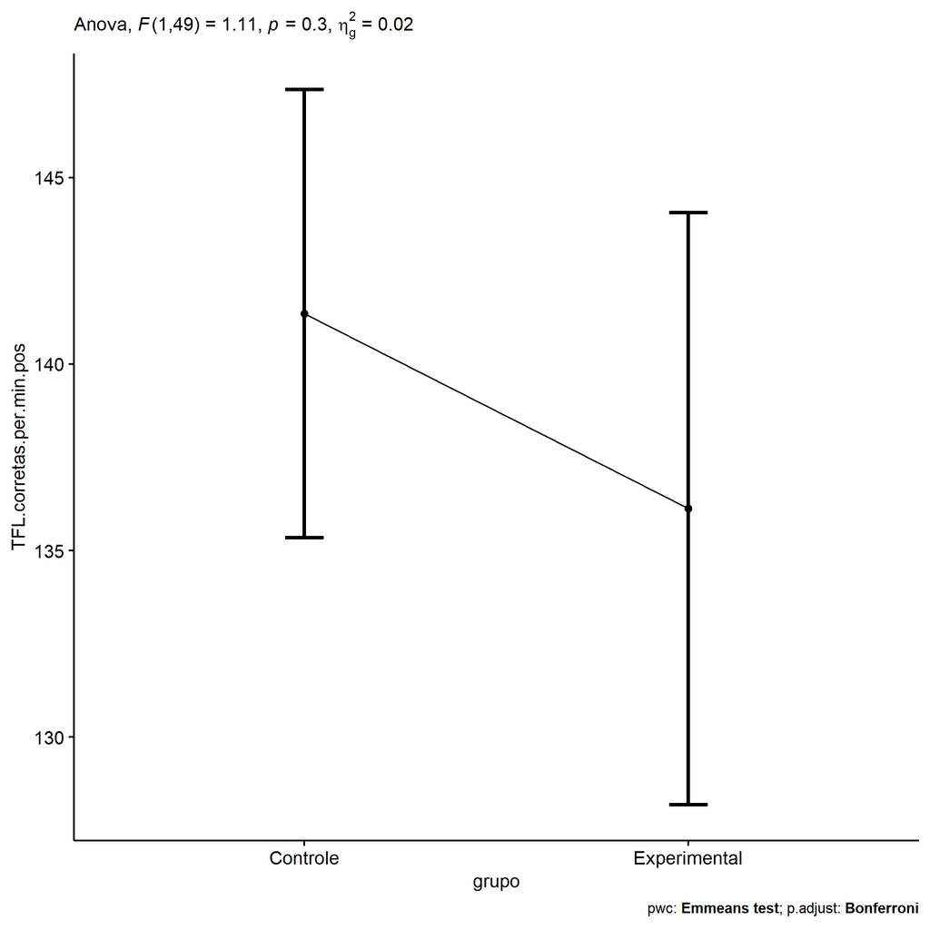

```r
if (!is.null(nrow(plots[["grupo"]]$data)))
  plots[["grupo"]] +
  if (ymin.ci < ymax.ci) ggplot2::ylim(ymin.ci, ymax.ci)
```

```r
plots <- oneWayAncovaBoxPlots(
  wdat, "TFL.corretas.per.min.pos", "grupo", aov, pwc, covar = "TFL.corretas.per.min.pre",
  theme = "classic", color = color[["grupo"]],
  subtitle = which(aov$Effect == "grupo"))
```

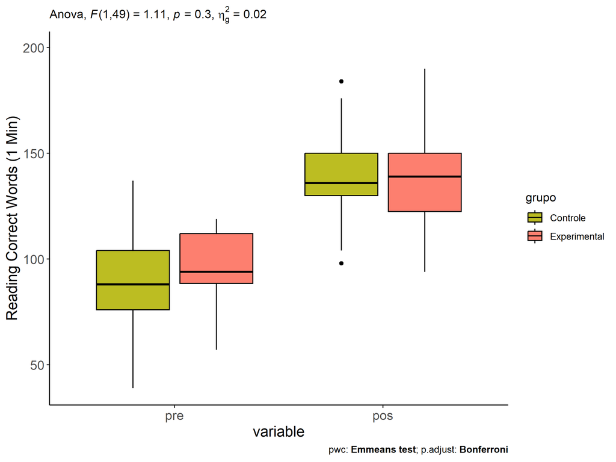

```r
if (length(unique(wdat[["grupo"]])) > 1)
  plots[["grupo"]] + ggplot2::ylab("Reading Correct Words (1 Min)") +
  ggplot2::scale_x_discrete(labels=c('pre', 'pos')) +
  if (ymin < ymax) ggplot2::ylim(ymin, ymax)
```

```r
if (length(unique(wdat.long[["grupo"]])) > 1)
  plots <- oneWayAncovaBoxPlots(
    wdat.long, "TFL.corretas.per.min", "grupo", aov, pwc.long,
    pre.post = "time", theme = "classic", color = color$prepost)
```

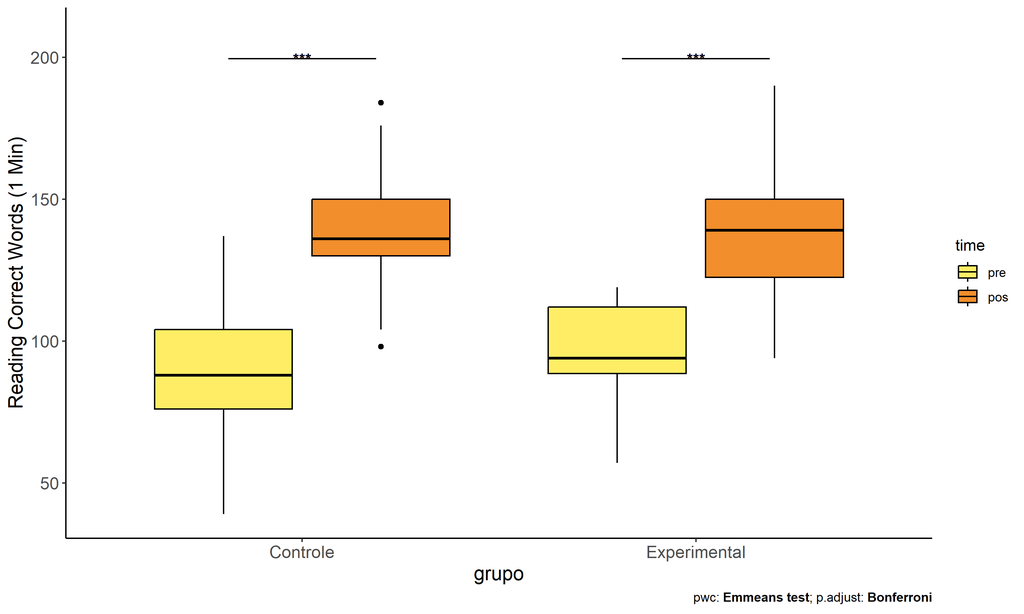

```r
if (length(unique(wdat.long[["grupo"]])) > 1)
  plots[["grupo"]] + ggplot2::ylab("Reading Correct Words (1 Min)") +
  if (ymin < ymax) ggplot2::ylim(ymin, ymax)
```

### Checking linearity assumption

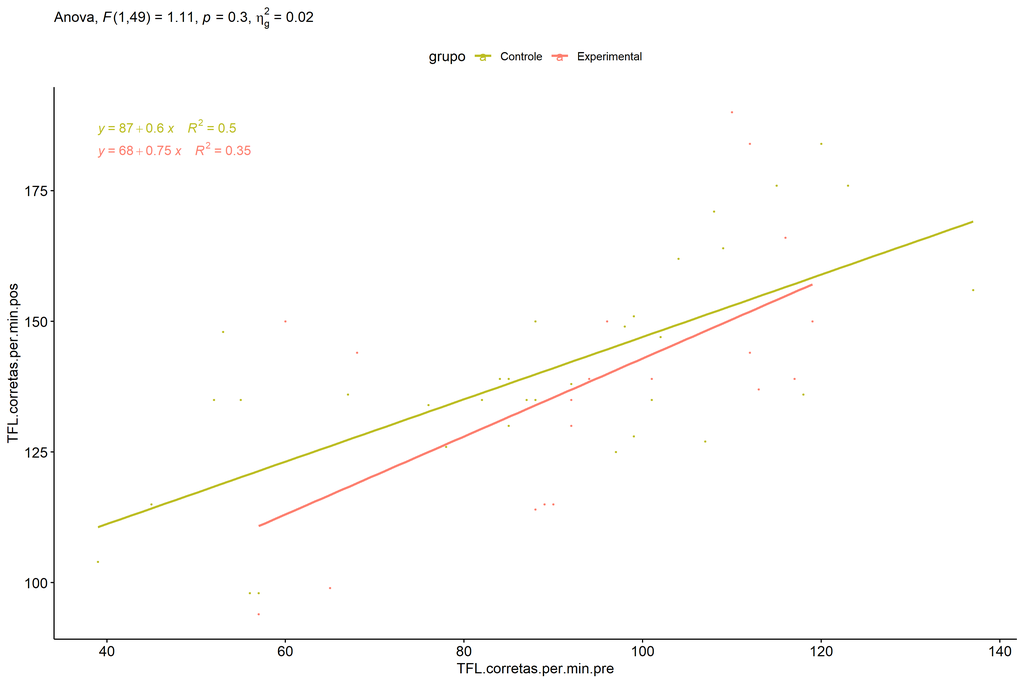

```r
ggscatter(wdat, x = "TFL.corretas.per.min.pre", y = "TFL.corretas.per.min.pos", size = 0.5,
          color = "grupo", add = "reg.line")+
  stat_regline_equation(
    aes(label =  paste(..eq.label.., ..rr.label.., sep = "~~~~"), color = grupo)
  ) +
  ggplot2::labs(subtitle = rstatix::get_test_label(aov, detailed = T, row = which(aov$Effect == "grupo"))) +
  ggplot2::scale_color_manual(values = color[["grupo"]]) +
  if (ymin < ymax) ggplot2::ylim(ymin, ymax)
```

### Checking normality and homogeneity

```r
res <- augment(lm(TFL.corretas.per.min.pos ~ TFL.corretas.per.min.pre + grupo, data = wdat))
```

```r
shapiro_test(res$.resid)
```

```
## # A tibble: 1 × 3
##   variable   statistic p.value
##   <chr>          <dbl>   <dbl>
## 1 res$.resid     0.955  0.0453
```

```r
levene_test(res, .resid ~ grupo)
```

```
## # A tibble: 1 × 4
##     df1   df2 statistic     p
##   <int> <int>     <dbl> <dbl>
## 1     1    50      1.40 0.242
```

# ANCOVA and Pairwise for two factors **grupo:Sexo**

## Without remove non-normal data

```r
pdat = remove_group_data(dat[!is.na(dat[["grupo"]]) & !is.na(dat[["Sexo"]]),],
                         "TFL.corretas.per.min.pos", c("grupo","Sexo"))
pdat = pdat[pdat[["Sexo"]] %in% do.call(
  intersect, lapply(unique(pdat[["grupo"]]), FUN = function(x) {
    unique(pdat[["Sexo"]][which(pdat[["grupo"]] == x)])
  })),]
pdat[["grupo"]] = factor(pdat[["grupo"]], level[["grupo"]])
pdat[["Sexo"]] = factor(
  pdat[["Sexo"]],
  level[["Sexo"]][level[["Sexo"]] %in% unique(pdat[["Sexo"]])])

pdat.long <- rbind(pdat[,c("id","grupo","Sexo")], pdat[,c("id","grupo","Sexo")])
pdat.long[["time"]] <- c(rep("pre", nrow(pdat)), rep("pos", nrow(pdat)))
pdat.long[["time"]] <- factor(pdat.long[["time"]], c("pre","pos"))
pdat.long[["TFL.corretas.per.min"]] <- c(pdat[["TFL.corretas.per.min.pre"]], pdat[["TFL.corretas.per.min.pos"]])

if (length(unique(pdat[["Sexo"]])) >= 2) {
  aov = anova_test(pdat, TFL.corretas.per.min.pos ~ TFL.corretas.per.min.pre + grupo*Sexo)
  laov[["grupo:Sexo"]] <- get_anova_table(aov)
}
```

```r
if (length(unique(pdat[["Sexo"]])) >= 2) {
  pwcs <- list()
  pwcs[["Sexo"]] <- emmeans_test(
    group_by(pdat, grupo), TFL.corretas.per.min.pos ~ Sexo,
    covariate = TFL.corretas.per.min.pre, p.adjust.method = "bonferroni")
  pwcs[["grupo"]] <- emmeans_test(
    group_by(pdat, Sexo), TFL.corretas.per.min.pos ~ grupo,
    covariate = TFL.corretas.per.min.pre, p.adjust.method = "bonferroni")

  pwc <- plyr::rbind.fill(pwcs[["grupo"]], pwcs[["Sexo"]])
  pwc <- pwc[,c("grupo","Sexo", colnames(pwc)[!colnames(pwc) %in% c("grupo","Sexo")])]
}
```

```r
if (length(unique(pdat[["Sexo"]])) >= 2) {
  pwc.long <- emmeans_test(dplyr::group_by_at(pdat.long, c("grupo","Sexo")),
                           TFL.corretas.per.min ~ time,
                           p.adjust.method = "bonferroni")
  lpwc[["grupo:Sexo"]] <- plyr::rbind.fill(pwc, pwc.long)
}
```

```r
if (length(unique(pdat[["Sexo"]])) >= 2) {
  ds <- get.descriptives(pdat, "TFL.corretas.per.min.pos", c("grupo","Sexo"), covar = "TFL.corretas.per.min.pre")
  ds <- merge(ds[ds$variable != "TFL.corretas.per.min.pre",],
              ds[ds$variable == "TFL.corretas.per.min.pre", !colnames(ds) %in% c("variable")],
              by = c("grupo","Sexo"), all.x = T, suffixes = c("", ".TFL.corretas.per.min.pre"))
  ds <- merge(get_emmeans(pwcs[["grupo"]]), ds,
              by = c("grupo","Sexo"), suffixes = c(".emms", ""))
  ds <- ds[,c("grupo","Sexo","n","mean.TFL.corretas.per.min.pre","se.TFL.corretas.per.min.pre","mean","se",
              "emmean","se.emms","conf.low","conf.high")]

  colnames(ds) <- c("grupo","Sexo", "N", paste0(c("M","SE")," (pre)"),
                    paste0(c("M","SE"), " (unadj)"),
                    paste0(c("M", "SE"), " (adj)"), "conf.low", "conf.high")

  lemms[["grupo:Sexo"]] <- ds
}
```

## Computing ANCOVA and PairWise After removing non-normal data (OK)

```r
if (length(unique(pdat[["Sexo"]])) >= 2) {
  wdat = pdat

  res = residuals(lm(TFL.corretas.per.min.pos ~ TFL.corretas.per.min.pre + grupo*Sexo, data = wdat))
  non.normal = getNonNormal(res, wdat$id, plimit = 0.05)

  wdat = wdat[!wdat$id %in% non.normal,]

  wdat.long <- rbind(wdat[,c("id","grupo","Sexo")], wdat[,c("id","grupo","Sexo")])
  wdat.long[["time"]] <- c(rep("pre", nrow(wdat)), rep("pos", nrow(wdat)))
  wdat.long[["time"]] <- factor(wdat.long[["time"]], c("pre","pos"))
  wdat.long[["TFL.corretas.per.min"]] <- c(wdat[["TFL.corretas.per.min.pre"]], wdat[["TFL.corretas.per.min.pos"]])


  ldat[["grupo:Sexo"]] = wdat

  (non.normal)
}
```

```
##  [1] "P463"  "P121"  "P1010" "P2250" "P945"  "P2378" "P808"  "P956"  "P2294" "P2220" "P1768"
## [12] "P2380" "P446"  "P3492" "P3721" "P510"  "P2385" "P3729" "P3498" "P133"  "P3516" "P1743"
## [23] "P623"  "P2211" "P3609" "P128"  "P445"  "P2377" "P2390" "P2408" "P3504" "P3512" "P2209"
## [34] "P1698" "P2247" "P2404" "P3521" "P1089" "P2240" "P2222" "P3505" "P2214" "P3524" "P1109"
## [45] "P521"  "P465"  "P3558" "P3581" "P942"  "P3501" "P621"  "P628"  "P1728" "P820"  "P994"
## [56] "P947"  "P184"  "P3566" "P3627" "P1713" "P1017" "P816"  "P2383" "P2401" "P1762" "P2376"
## [67] "P1097" "P3615" "P3630" "P3495" "P1699" "P2244" "P448"  "P241"  "P1716" "P615"  "P3511"
## [78] "P1091" "P950"  "P460"  "P1022" "P2402" "P1764" "P941"
```

```r
if (length(unique(pdat[["Sexo"]])) >= 2) {
  aov = anova_test(wdat, TFL.corretas.per.min.pos ~ TFL.corretas.per.min.pre + grupo*Sexo)
  laov[["grupo:Sexo"]] <- merge(get_anova_table(aov), laov[["grupo:Sexo"]],
                                         by="Effect", suffixes = c("","'"))
  df = get_anova_table(aov)
}
```

| Effect | DFn | DFd | F | p | p<.05 | ges |
| --- | --- | --- | --- | --- | --- | --- |
| TFL.corretas.per.min.pre | 1 | 54 | 216.425 | 0.000 | * | 0.800 |
| grupo | 1 | 54 | 0.018 | 0.893 |  | 0.000 |
| Sexo | 1 | 54 | 26.602 | 0.000 | * | 0.330 |
| grupo:Sexo | 1 | 54 | 3.690 | 0.060 |  | 0.064 |

```r
if (length(unique(pdat[["Sexo"]])) >= 2) {
  pwcs <- list()
  pwcs[["Sexo"]] <- emmeans_test(
    group_by(wdat, grupo), TFL.corretas.per.min.pos ~ Sexo,
    covariate = TFL.corretas.per.min.pre, p.adjust.method = "bonferroni")
  pwcs[["grupo"]] <- emmeans_test(
    group_by(wdat, Sexo), TFL.corretas.per.min.pos ~ grupo,
    covariate = TFL.corretas.per.min.pre, p.adjust.method = "bonferroni")

  pwc <- plyr::rbind.fill(pwcs[["grupo"]], pwcs[["Sexo"]])
  pwc <- pwc[,c("grupo","Sexo", colnames(pwc)[!colnames(pwc) %in% c("grupo","Sexo")])]
}
```

| grupo | Sexo | term | .y. | group1 | group2 | df | statistic | p | p.adj | p.adj.signif |
| --- | --- | --- | --- | --- | --- | --- | --- | --- | --- | --- |
|  | F | TFL.corretas.per.min.pre*grupo | TFL.corretas.per.min.pos | Controle | Experimental | 54 | -1.620 | 0.111 | 0.111 | ns |
|  | M | TFL.corretas.per.min.pre*grupo | TFL.corretas.per.min.pos | Controle | Experimental | 54 | 1.078 | 0.286 | 0.286 | ns |
| Controle |  | TFL.corretas.per.min.pre*Sexo | TFL.corretas.per.min.pos | F | M | 54 | 2.633 | 0.011 | 0.011 | * |
| Experimental |  | TFL.corretas.per.min.pre*Sexo | TFL.corretas.per.min.pos | F | M | 54 | 4.769 | 0.000 | 0.000 | **** |

```r
if (length(unique(pdat[["Sexo"]])) >= 2) {
  pwc.long <- emmeans_test(dplyr::group_by_at(wdat.long, c("grupo","Sexo")),
                           TFL.corretas.per.min ~ time,
                           p.adjust.method = "bonferroni")
  lpwc[["grupo:Sexo"]] <- merge(plyr::rbind.fill(pwc, pwc.long),
                                         lpwc[["grupo:Sexo"]],
                                         by=c("grupo","Sexo","term",".y.","group1","group2"),
                                         suffixes = c("","'"))
}
```

| grupo | Sexo | term | .y. | group1 | group2 | df | statistic | p | p.adj | p.adj.signif |
| --- | --- | --- | --- | --- | --- | --- | --- | --- | --- | --- |
| Controle | F | time | TFL.corretas.per.min | pre | pos | 110 | -3.380 | 0.001 | 0.001 | ** |
| Controle | M | time | TFL.corretas.per.min | pre | pos | 110 | -1.983 | 0.050 | 0.050 | * |
| Experimental | F | time | TFL.corretas.per.min | pre | pos | 110 | -2.442 | 0.016 | 0.016 | * |
| Experimental | M | time | TFL.corretas.per.min | pre | pos | 110 | -2.231 | 0.028 | 0.028 | * |

```r
if (length(unique(pdat[["Sexo"]])) >= 2) {
  ds <- get.descriptives(wdat, "TFL.corretas.per.min.pos", c("grupo","Sexo"), covar = "TFL.corretas.per.min.pre")
  ds <- merge(ds[ds$variable != "TFL.corretas.per.min.pre",],
              ds[ds$variable == "TFL.corretas.per.min.pre", !colnames(ds) %in% c("variable")],
              by = c("grupo","Sexo"), all.x = T, suffixes = c("", ".TFL.corretas.per.min.pre"))
  ds <- merge(get_emmeans(pwcs[["grupo"]]), ds,
              by = c("grupo","Sexo"), suffixes = c(".emms", ""))
  ds <- ds[,c("grupo","Sexo","n","mean.TFL.corretas.per.min.pre","se.TFL.corretas.per.min.pre",
              "mean","se","emmean","se.emms","conf.low","conf.high")]

  colnames(ds) <- c("grupo","Sexo", "N", paste0(c("M","SE")," (pre)"),
                    paste0(c("M","SE"), " (unadj)"),
                    paste0(c("M", "SE"), " (adj)"), "conf.low", "conf.high")

  lemms[["grupo:Sexo"]] <- merge(ds, lemms[["grupo:Sexo"]],
                                          by=c("grupo","Sexo"), suffixes = c("","'"))
}
```

| grupo | Sexo | N | M (pre) | SE (pre) | M (unadj) | SE (unadj) | M (adj) | SE (adj) | conf.low | conf.high |
| --- | --- | --- | --- | --- | --- | --- | --- | --- | --- | --- |
| Controle | F | 15 | 86.600 | 7.768 | 112.000 | 4.136 | 115.427 | 1.877 | 111.664 | 119.190 |
| Controle | M | 17 | 97.706 | 5.989 | 111.706 | 4.312 | 108.597 | 1.762 | 105.064 | 112.130 |
| Experimental | F | 8 | 99.875 | 4.879 | 125.000 | 5.155 | 120.615 | 2.568 | 115.467 | 125.763 |
| Experimental | M | 19 | 89.158 | 5.059 | 104.053 | 3.391 | 105.975 | 1.660 | 102.646 | 109.303 |

### Plots for ancova

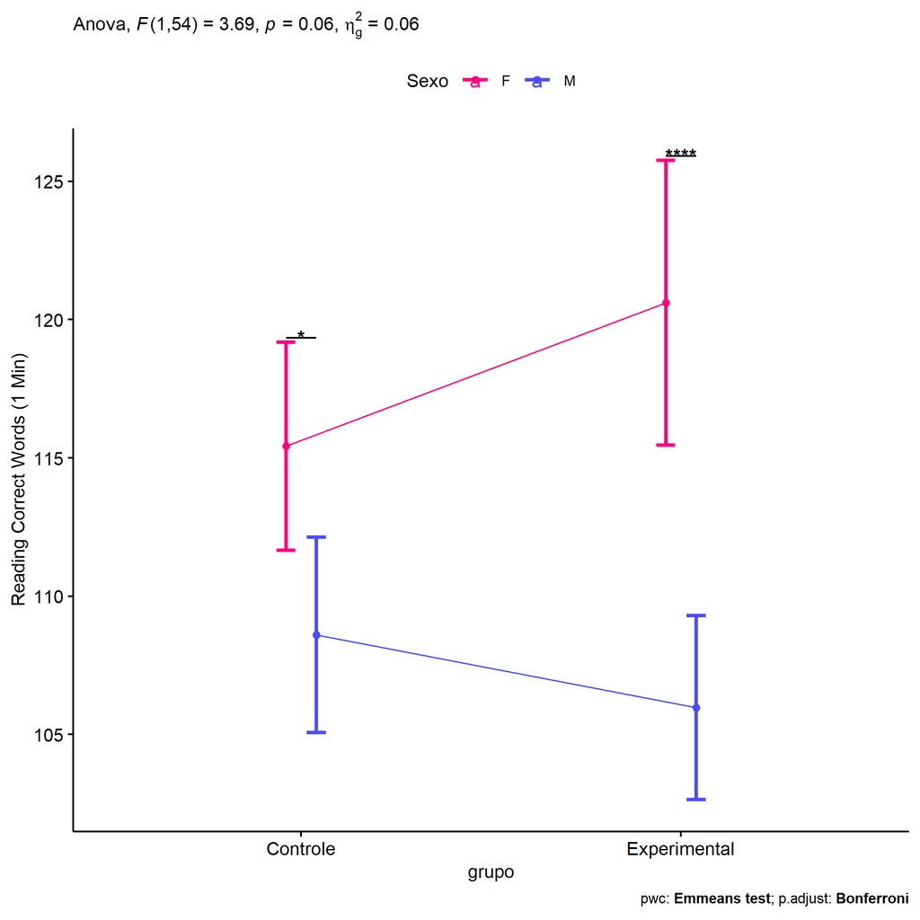

```r
if (length(unique(pdat[["Sexo"]])) >= 2) {
  ggPlotAoC2(pwcs, "grupo", "Sexo", aov, ylab = "Reading Correct Words (1 Min)",
             subtitle = which(aov$Effect == "grupo:Sexo"), addParam = "errorbar") +
    ggplot2::scale_color_manual(values = color[["Sexo"]]) +
    if (ymin.ci < ymax.ci) ggplot2::ylim(ymin.ci, ymax.ci)
}
```

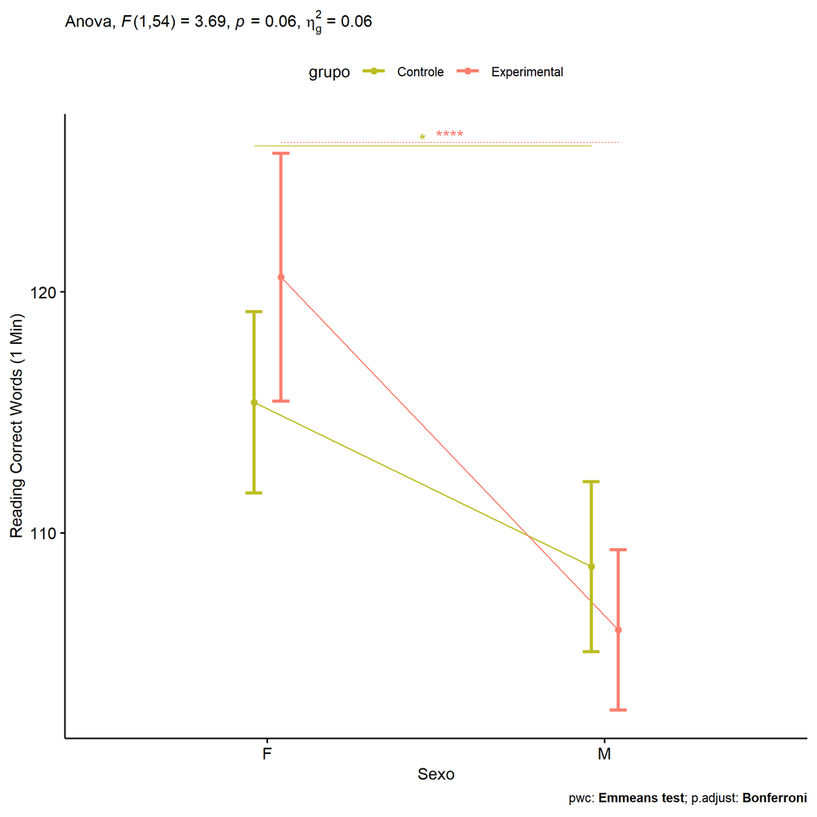

```r
if (length(unique(pdat[["Sexo"]])) >= 2) {
  ggPlotAoC2(pwcs, "Sexo", "grupo", aov, ylab = "Reading Correct Words (1 Min)",
               subtitle = which(aov$Effect == "grupo:Sexo"), addParam = "errorbar") +
      ggplot2::scale_color_manual(values = color[["grupo"]]) +
      if (ymin.ci < ymax.ci) ggplot2::ylim(ymin.ci, ymax.ci)
}
```

```r
if (length(unique(pdat[["Sexo"]])) >= 2) {
  plots <- twoWayAncovaBoxPlots(
    wdat, "TFL.corretas.per.min.pos", c("grupo","Sexo"), aov, pwcs, covar = "TFL.corretas.per.min.pre",
    theme = "classic", color = color[["grupo:Sexo"]],
    subtitle = which(aov$Effect == "grupo:Sexo"))
}
```

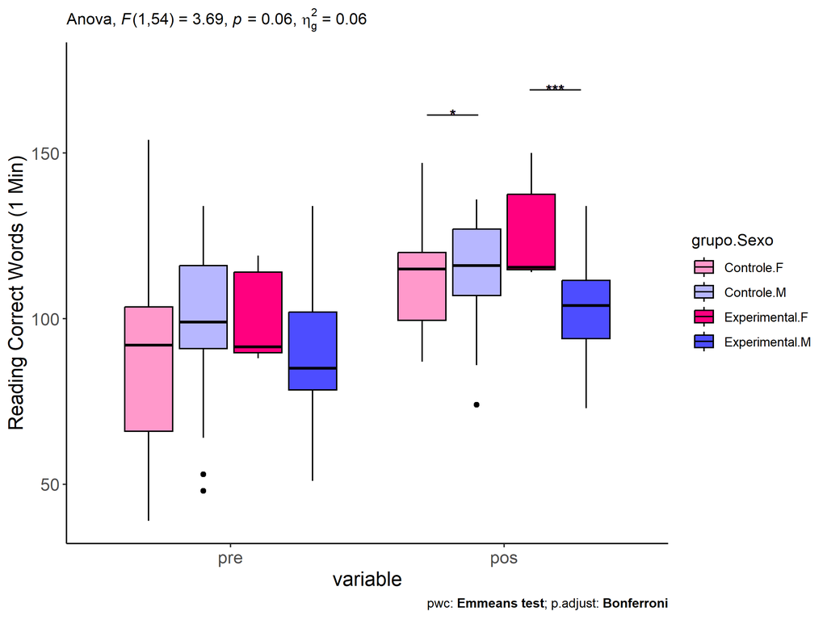

```r
if (length(unique(pdat[["Sexo"]])) >= 2) {
  plots[["grupo:Sexo"]] + ggplot2::ylab("Reading Correct Words (1 Min)") +
  ggplot2::scale_x_discrete(labels=c('pre', 'pos')) +
  if (ymin < ymax) ggplot2::ylim(ymin, ymax)
}
```

```r
if (length(unique(pdat[["Sexo"]])) >= 2) {
  plots <- twoWayAncovaBoxPlots(
    wdat.long, "TFL.corretas.per.min", c("grupo","Sexo"), aov, pwc.long,
    pre.post = "time",
    theme = "classic", color = color$prepost)
}
```

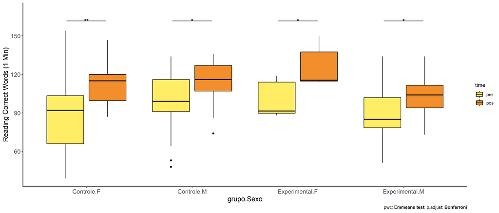

```r
if (length(unique(pdat[["Sexo"]])) >= 2)
  plots[["grupo:Sexo"]] + ggplot2::ylab("Reading Correct Words (1 Min)") +
    if (ymin < ymax) ggplot2::ylim(ymin, ymax)
```

### Checking linearity assumption

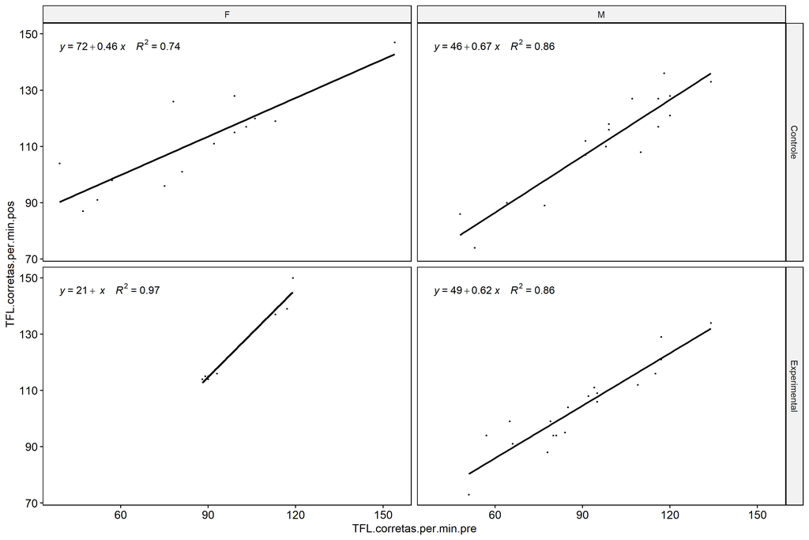

```r
if (length(unique(pdat[["Sexo"]])) >= 2) {
  ggscatter(wdat, x = "TFL.corretas.per.min.pre", y = "TFL.corretas.per.min.pos", size = 0.5,
            facet.by = c("grupo","Sexo"), add = "reg.line")+
    stat_regline_equation(
      aes(label =  paste(..eq.label.., ..rr.label.., sep = "~~~~"))
    ) +
    if (ymin < ymax) ggplot2::ylim(ymin, ymax)
}
```

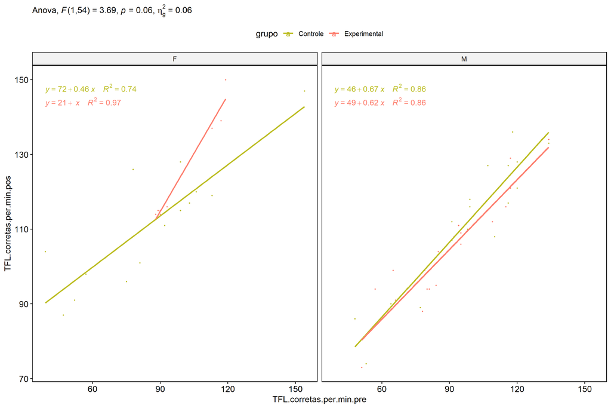

```r
if (length(unique(pdat[["Sexo"]])) >= 2) {
  ggscatter(wdat, x = "TFL.corretas.per.min.pre", y = "TFL.corretas.per.min.pos", size = 0.5,
            color = "grupo", facet.by = "Sexo", add = "reg.line")+
    stat_regline_equation(
      aes(label =  paste(..eq.label.., ..rr.label.., sep = "~~~~"), color = grupo)
    ) +
    ggplot2::labs(subtitle = rstatix::get_test_label(aov, detailed = T, row = which(aov$Effect == "grupo:Sexo"))) +
    ggplot2::scale_color_manual(values = color[["grupo"]]) +
    if (ymin < ymax) ggplot2::ylim(ymin, ymax)
}
```

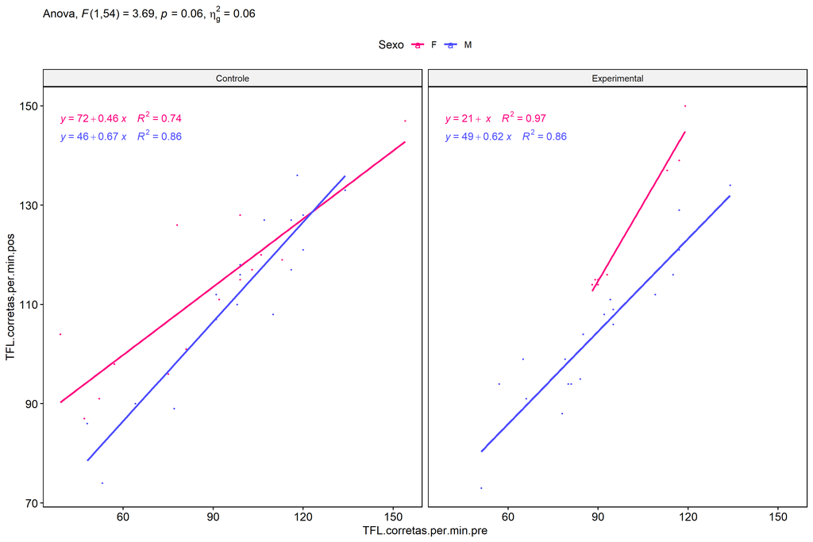

```r
if (length(unique(pdat[["Sexo"]])) >= 2) {
  ggscatter(wdat, x = "TFL.corretas.per.min.pre", y = "TFL.corretas.per.min.pos", size = 0.5,
            color = "Sexo", facet.by = "grupo", add = "reg.line")+
    stat_regline_equation(
      aes(label =  paste(..eq.label.., ..rr.label.., sep = "~~~~"), color = Sexo)
    ) +
    ggplot2::labs(subtitle = rstatix::get_test_label(aov, detailed = T, row = which(aov$Effect == "grupo:Sexo"))) +
    ggplot2::scale_color_manual(values = color[["Sexo"]]) +
    if (ymin < ymax) ggplot2::ylim(ymin, ymax)
}
```

### Checking normality and homogeneity

```r
if (length(unique(pdat[["Sexo"]])) >= 2)
  res <- augment(lm(TFL.corretas.per.min.pos ~ TFL.corretas.per.min.pre + grupo*Sexo, data = wdat))
```

```r
if (length(unique(pdat[["Sexo"]])) >= 2)
  shapiro_test(res$.resid)
```

```
## # A tibble: 1 × 3
##   variable   statistic p.value
##   <chr>          <dbl>   <dbl>
## 1 res$.resid     0.951  0.0190
```

```r
if (length(unique(pdat[["Sexo"]])) >= 2)
  levene_test(res, .resid ~ grupo*Sexo)
```

```
## # A tibble: 1 × 4
##     df1   df2 statistic     p
##   <int> <int>     <dbl> <dbl>
## 1     3    55     0.316 0.814
```

# ANCOVA and Pairwise for two factors **grupo:Zona**

## Without remove non-normal data

```r
pdat = remove_group_data(dat[!is.na(dat[["grupo"]]) & !is.na(dat[["Zona"]]),],
                         "TFL.corretas.per.min.pos", c("grupo","Zona"))
pdat = pdat[pdat[["Zona"]] %in% do.call(
  intersect, lapply(unique(pdat[["grupo"]]), FUN = function(x) {
    unique(pdat[["Zona"]][which(pdat[["grupo"]] == x)])
  })),]
pdat[["grupo"]] = factor(pdat[["grupo"]], level[["grupo"]])
pdat[["Zona"]] = factor(
  pdat[["Zona"]],
  level[["Zona"]][level[["Zona"]] %in% unique(pdat[["Zona"]])])

pdat.long <- rbind(pdat[,c("id","grupo","Zona")], pdat[,c("id","grupo","Zona")])
pdat.long[["time"]] <- c(rep("pre", nrow(pdat)), rep("pos", nrow(pdat)))
pdat.long[["time"]] <- factor(pdat.long[["time"]], c("pre","pos"))
pdat.long[["TFL.corretas.per.min"]] <- c(pdat[["TFL.corretas.per.min.pre"]], pdat[["TFL.corretas.per.min.pos"]])

if (length(unique(pdat[["Zona"]])) >= 2) {
  aov = anova_test(pdat, TFL.corretas.per.min.pos ~ TFL.corretas.per.min.pre + grupo*Zona)
  laov[["grupo:Zona"]] <- get_anova_table(aov)
}
```

```r
if (length(unique(pdat[["Zona"]])) >= 2) {
  pwcs <- list()
  pwcs[["Zona"]] <- emmeans_test(
    group_by(pdat, grupo), TFL.corretas.per.min.pos ~ Zona,
    covariate = TFL.corretas.per.min.pre, p.adjust.method = "bonferroni")
  pwcs[["grupo"]] <- emmeans_test(
    group_by(pdat, Zona), TFL.corretas.per.min.pos ~ grupo,
    covariate = TFL.corretas.per.min.pre, p.adjust.method = "bonferroni")

  pwc <- plyr::rbind.fill(pwcs[["grupo"]], pwcs[["Zona"]])
  pwc <- pwc[,c("grupo","Zona", colnames(pwc)[!colnames(pwc) %in% c("grupo","Zona")])]
}
```

```r
if (length(unique(pdat[["Zona"]])) >= 2) {
  pwc.long <- emmeans_test(dplyr::group_by_at(pdat.long, c("grupo","Zona")),
                           TFL.corretas.per.min ~ time,
                           p.adjust.method = "bonferroni")
  lpwc[["grupo:Zona"]] <- plyr::rbind.fill(pwc, pwc.long)
}
```

```r
if (length(unique(pdat[["Zona"]])) >= 2) {
  ds <- get.descriptives(pdat, "TFL.corretas.per.min.pos", c("grupo","Zona"), covar = "TFL.corretas.per.min.pre")
  ds <- merge(ds[ds$variable != "TFL.corretas.per.min.pre",],
              ds[ds$variable == "TFL.corretas.per.min.pre", !colnames(ds) %in% c("variable")],
              by = c("grupo","Zona"), all.x = T, suffixes = c("", ".TFL.corretas.per.min.pre"))
  ds <- merge(get_emmeans(pwcs[["grupo"]]), ds,
              by = c("grupo","Zona"), suffixes = c(".emms", ""))
  ds <- ds[,c("grupo","Zona","n","mean.TFL.corretas.per.min.pre","se.TFL.corretas.per.min.pre","mean","se",
              "emmean","se.emms","conf.low","conf.high")]

  colnames(ds) <- c("grupo","Zona", "N", paste0(c("M","SE")," (pre)"),
                    paste0(c("M","SE"), " (unadj)"),
                    paste0(c("M", "SE"), " (adj)"), "conf.low", "conf.high")

  lemms[["grupo:Zona"]] <- ds
}
```

## Computing ANCOVA and PairWise After removing non-normal data (OK)

```r
if (length(unique(pdat[["Zona"]])) >= 2) {
  wdat = pdat

  res = residuals(lm(TFL.corretas.per.min.pos ~ TFL.corretas.per.min.pre + grupo*Zona, data = wdat))
  non.normal = getNonNormal(res, wdat$id, plimit = 0.05)

  wdat = wdat[!wdat$id %in% non.normal,]

  wdat.long <- rbind(wdat[,c("id","grupo","Zona")], wdat[,c("id","grupo","Zona")])
  wdat.long[["time"]] <- c(rep("pre", nrow(wdat)), rep("pos", nrow(wdat)))
  wdat.long[["time"]] <- factor(wdat.long[["time"]], c("pre","pos"))
  wdat.long[["TFL.corretas.per.min"]] <- c(wdat[["TFL.corretas.per.min.pre"]], wdat[["TFL.corretas.per.min.pos"]])


  ldat[["grupo:Zona"]] = wdat

  (non.normal)
}
```

```
## [1] "P510"  "P1768" "P1743" "P2378" "P945"  "P1698" "P2220"
```

```r
if (length(unique(pdat[["Zona"]])) >= 2) {
  aov = anova_test(wdat, TFL.corretas.per.min.pos ~ TFL.corretas.per.min.pre + grupo*Zona)
  laov[["grupo:Zona"]] <- merge(get_anova_table(aov), laov[["grupo:Zona"]],
                                         by="Effect", suffixes = c("","'"))
  df = get_anova_table(aov)
}
```

| Effect | DFn | DFd | F | p | p<.05 | ges |
| --- | --- | --- | --- | --- | --- | --- |
| TFL.corretas.per.min.pre | 1 | 94 | 76.601 | 0.000 | * | 0.449 |
| grupo | 1 | 94 | 0.011 | 0.918 |  | 0.000 |
| Zona | 1 | 94 | 42.906 | 0.000 | * | 0.313 |
| grupo:Zona | 1 | 94 | 3.994 | 0.049 | * | 0.041 |

```r
if (length(unique(pdat[["Zona"]])) >= 2) {
  pwcs <- list()
  pwcs[["Zona"]] <- emmeans_test(
    group_by(wdat, grupo), TFL.corretas.per.min.pos ~ Zona,
    covariate = TFL.corretas.per.min.pre, p.adjust.method = "bonferroni")
  pwcs[["grupo"]] <- emmeans_test(
    group_by(wdat, Zona), TFL.corretas.per.min.pos ~ grupo,
    covariate = TFL.corretas.per.min.pre, p.adjust.method = "bonferroni")

  pwc <- plyr::rbind.fill(pwcs[["grupo"]], pwcs[["Zona"]])
  pwc <- pwc[,c("grupo","Zona", colnames(pwc)[!colnames(pwc) %in% c("grupo","Zona")])]
}
```

| grupo | Zona | term | .y. | group1 | group2 | df | statistic | p | p.adj | p.adj.signif |
| --- | --- | --- | --- | --- | --- | --- | --- | --- | --- | --- |
|  | Rural | TFL.corretas.per.min.pre*grupo | TFL.corretas.per.min.pos | Controle | Experimental | 94 | -0.841 | 0.403 | 0.403 | ns |
|  | Urbana | TFL.corretas.per.min.pre*grupo | TFL.corretas.per.min.pos | Controle | Experimental | 94 | 1.817 | 0.072 | 0.072 | ns |
| Controle |  | TFL.corretas.per.min.pre*Zona | TFL.corretas.per.min.pos | Rural | Urbana | 94 | -6.213 | 0.000 | 0.000 | **** |
| Experimental |  | TFL.corretas.per.min.pre*Zona | TFL.corretas.per.min.pos | Rural | Urbana | 94 | -2.890 | 0.005 | 0.005 | ** |

```r
if (length(unique(pdat[["Zona"]])) >= 2) {
  pwc.long <- emmeans_test(dplyr::group_by_at(wdat.long, c("grupo","Zona")),
                           TFL.corretas.per.min ~ time,
                           p.adjust.method = "bonferroni")
  lpwc[["grupo:Zona"]] <- merge(plyr::rbind.fill(pwc, pwc.long),
                                         lpwc[["grupo:Zona"]],
                                         by=c("grupo","Zona","term",".y.","group1","group2"),
                                         suffixes = c("","'"))
}
```

| grupo | Zona | term | .y. | group1 | group2 | df | statistic | p | p.adj | p.adj.signif |
| --- | --- | --- | --- | --- | --- | --- | --- | --- | --- | --- |
| Controle | Rural | time | TFL.corretas.per.min | pre | pos | 190 | -2.328 | 0.021 | 0.021 | * |
| Controle | Urbana | time | TFL.corretas.per.min | pre | pos | 190 | -4.142 | 0.000 | 0.000 | **** |
| Experimental | Rural | time | TFL.corretas.per.min | pre | pos | 190 | -2.406 | 0.017 | 0.017 | * |
| Experimental | Urbana | time | TFL.corretas.per.min | pre | pos | 190 | -2.294 | 0.023 | 0.023 | * |

```r
if (length(unique(pdat[["Zona"]])) >= 2) {
  ds <- get.descriptives(wdat, "TFL.corretas.per.min.pos", c("grupo","Zona"), covar = "TFL.corretas.per.min.pre")
  ds <- merge(ds[ds$variable != "TFL.corretas.per.min.pre",],
              ds[ds$variable == "TFL.corretas.per.min.pre", !colnames(ds) %in% c("variable")],
              by = c("grupo","Zona"), all.x = T, suffixes = c("", ".TFL.corretas.per.min.pre"))
  ds <- merge(get_emmeans(pwcs[["grupo"]]), ds,
              by = c("grupo","Zona"), suffixes = c(".emms", ""))
  ds <- ds[,c("grupo","Zona","n","mean.TFL.corretas.per.min.pre","se.TFL.corretas.per.min.pre",
              "mean","se","emmean","se.emms","conf.low","conf.high")]

  colnames(ds) <- c("grupo","Zona", "N", paste0(c("M","SE")," (pre)"),
                    paste0(c("M","SE"), " (unadj)"),
                    paste0(c("M", "SE"), " (adj)"), "conf.low", "conf.high")

  lemms[["grupo:Zona"]] <- merge(ds, lemms[["grupo:Zona"]],
                                          by=c("grupo","Zona"), suffixes = c("","'"))
}
```

| grupo | Zona | N | M (pre) | SE (pre) | M (unadj) | SE (unadj) | M (adj) | SE (adj) | conf.low | conf.high |
| --- | --- | --- | --- | --- | --- | --- | --- | --- | --- | --- |
| Controle | Rural | 54 | 91.111 | 3.608 | 101.259 | 2.955 | 101.490 | 2.205 | 97.112 | 105.868 |
| Controle | Urbana | 7 | 92.286 | 9.097 | 142.429 | 10.792 | 141.934 | 6.124 | 129.774 | 154.094 |
| Experimental | Rural | 32 | 89.969 | 3.268 | 103.594 | 3.038 | 104.530 | 2.866 | 98.840 | 110.221 |
| Experimental | Urbana | 6 | 102.000 | 6.713 | 132.000 | 13.849 | 125.503 | 6.656 | 112.288 | 138.719 |

### Plots for ancova

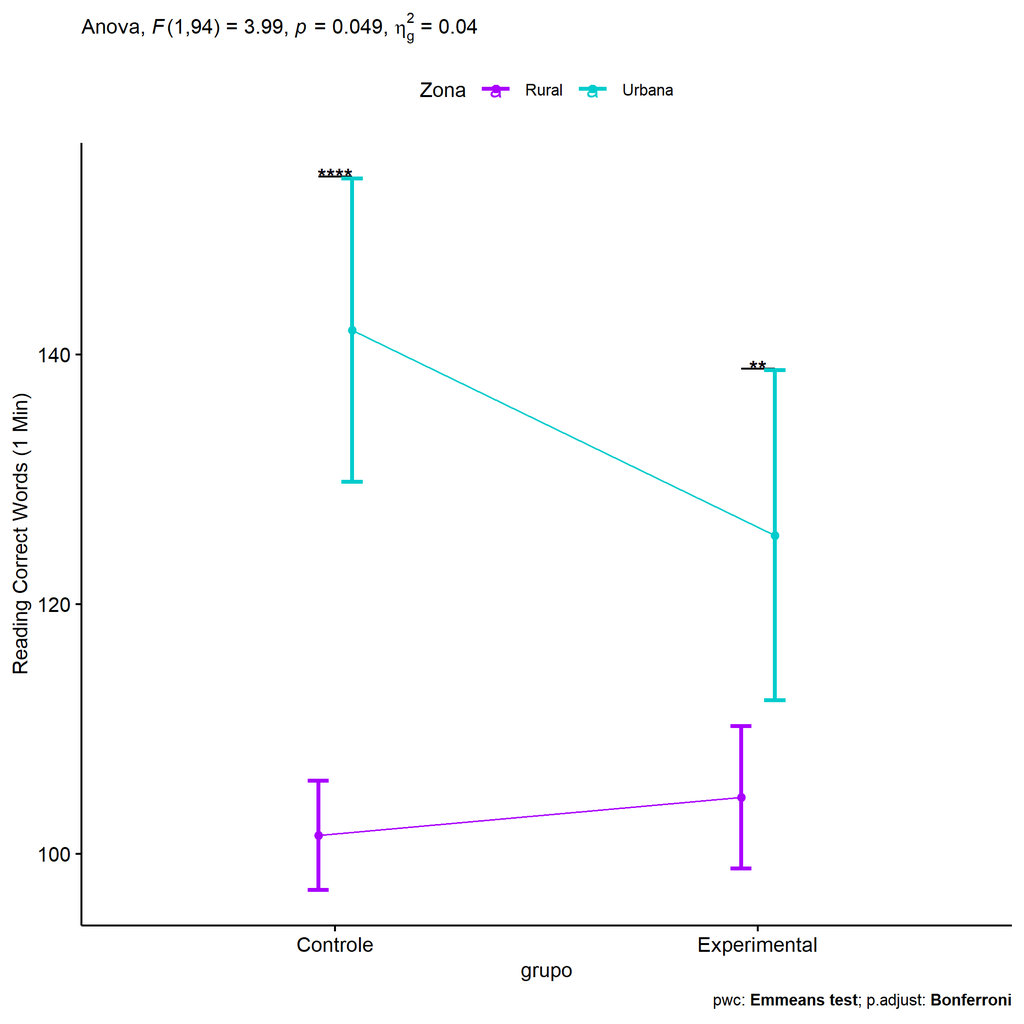

```r
if (length(unique(pdat[["Zona"]])) >= 2) {
  ggPlotAoC2(pwcs, "grupo", "Zona", aov, ylab = "Reading Correct Words (1 Min)",
             subtitle = which(aov$Effect == "grupo:Zona"), addParam = "errorbar") +
    ggplot2::scale_color_manual(values = color[["Zona"]]) +
    if (ymin.ci < ymax.ci) ggplot2::ylim(ymin.ci, ymax.ci)
}
```

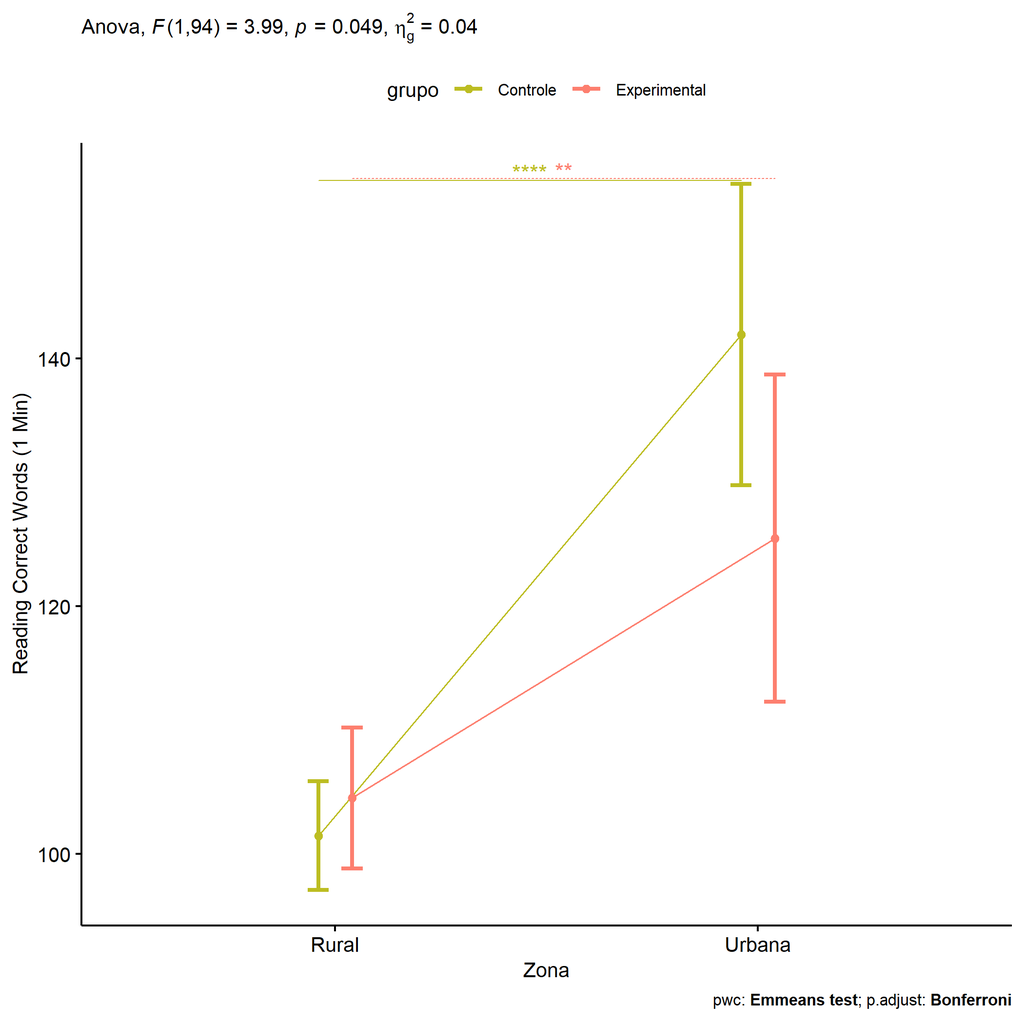

```r
if (length(unique(pdat[["Zona"]])) >= 2) {
  ggPlotAoC2(pwcs, "Zona", "grupo", aov, ylab = "Reading Correct Words (1 Min)",
               subtitle = which(aov$Effect == "grupo:Zona"), addParam = "errorbar") +
      ggplot2::scale_color_manual(values = color[["grupo"]]) +
      if (ymin.ci < ymax.ci) ggplot2::ylim(ymin.ci, ymax.ci)
}
```

```r
if (length(unique(pdat[["Zona"]])) >= 2) {
  plots <- twoWayAncovaBoxPlots(
    wdat, "TFL.corretas.per.min.pos", c("grupo","Zona"), aov, pwcs, covar = "TFL.corretas.per.min.pre",
    theme = "classic", color = color[["grupo:Zona"]],
    subtitle = which(aov$Effect == "grupo:Zona"))
}
```

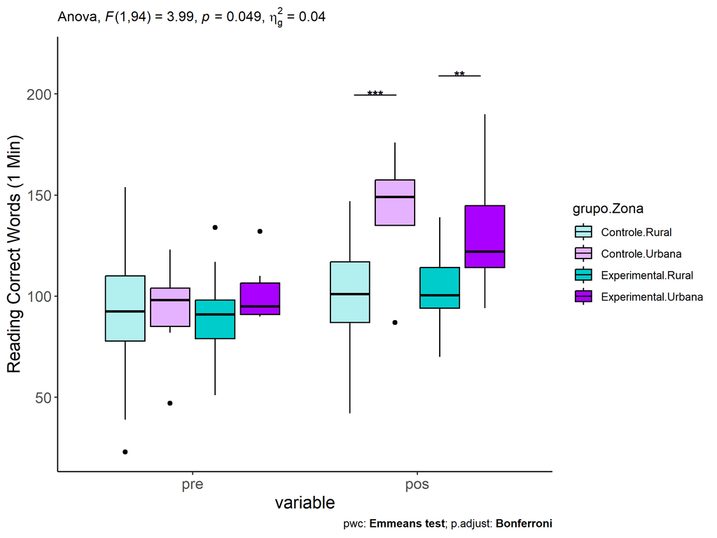

```r
if (length(unique(pdat[["Zona"]])) >= 2) {
  plots[["grupo:Zona"]] + ggplot2::ylab("Reading Correct Words (1 Min)") +
  ggplot2::scale_x_discrete(labels=c('pre', 'pos')) +
  if (ymin < ymax) ggplot2::ylim(ymin, ymax)
}
```

```r
if (length(unique(pdat[["Zona"]])) >= 2) {
  plots <- twoWayAncovaBoxPlots(
    wdat.long, "TFL.corretas.per.min", c("grupo","Zona"), aov, pwc.long,
    pre.post = "time",
    theme = "classic", color = color$prepost)
}
```

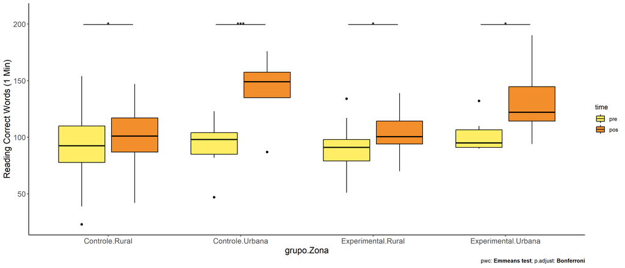

```r
if (length(unique(pdat[["Zona"]])) >= 2)
  plots[["grupo:Zona"]] + ggplot2::ylab("Reading Correct Words (1 Min)") +
    if (ymin < ymax) ggplot2::ylim(ymin, ymax)
```

### Checking linearity assumption

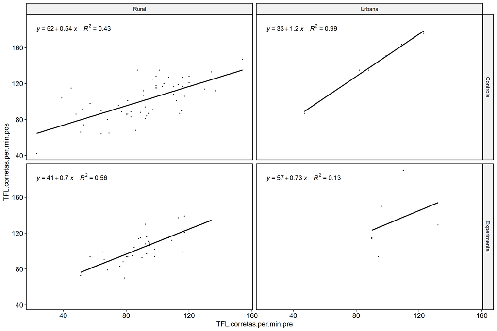

```r
if (length(unique(pdat[["Zona"]])) >= 2) {
  ggscatter(wdat, x = "TFL.corretas.per.min.pre", y = "TFL.corretas.per.min.pos", size = 0.5,
            facet.by = c("grupo","Zona"), add = "reg.line")+
    stat_regline_equation(
      aes(label =  paste(..eq.label.., ..rr.label.., sep = "~~~~"))
    ) +
    if (ymin < ymax) ggplot2::ylim(ymin, ymax)
}
```

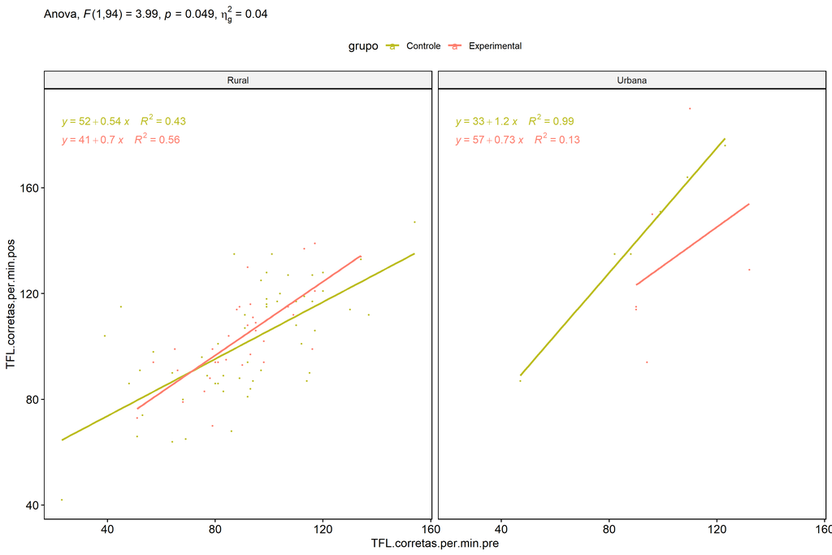

```r
if (length(unique(pdat[["Zona"]])) >= 2) {
  ggscatter(wdat, x = "TFL.corretas.per.min.pre", y = "TFL.corretas.per.min.pos", size = 0.5,
            color = "grupo", facet.by = "Zona", add = "reg.line")+
    stat_regline_equation(
      aes(label =  paste(..eq.label.., ..rr.label.., sep = "~~~~"), color = grupo)
    ) +
    ggplot2::labs(subtitle = rstatix::get_test_label(aov, detailed = T, row = which(aov$Effect == "grupo:Zona"))) +
    ggplot2::scale_color_manual(values = color[["grupo"]]) +
    if (ymin < ymax) ggplot2::ylim(ymin, ymax)
}
```

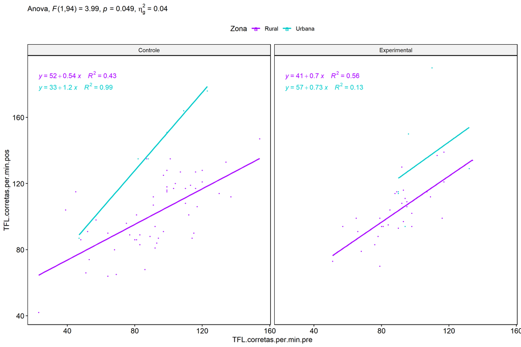

```r
if (length(unique(pdat[["Zona"]])) >= 2) {
  ggscatter(wdat, x = "TFL.corretas.per.min.pre", y = "TFL.corretas.per.min.pos", size = 0.5,
            color = "Zona", facet.by = "grupo", add = "reg.line")+
    stat_regline_equation(
      aes(label =  paste(..eq.label.., ..rr.label.., sep = "~~~~"), color = Zona)
    ) +
    ggplot2::labs(subtitle = rstatix::get_test_label(aov, detailed = T, row = which(aov$Effect == "grupo:Zona"))) +
    ggplot2::scale_color_manual(values = color[["Zona"]]) +
    if (ymin < ymax) ggplot2::ylim(ymin, ymax)
}
```

### Checking normality and homogeneity

```r
if (length(unique(pdat[["Zona"]])) >= 2)
  res <- augment(lm(TFL.corretas.per.min.pos ~ TFL.corretas.per.min.pre + grupo*Zona, data = wdat))
```

```r
if (length(unique(pdat[["Zona"]])) >= 2)
  shapiro_test(res$.resid)
```

```
## # A tibble: 1 × 3
##   variable   statistic p.value
##   <chr>          <dbl>   <dbl>
## 1 res$.resid     0.980   0.133
```

```r
if (length(unique(pdat[["Zona"]])) >= 2)
  levene_test(res, .resid ~ grupo*Zona)
```

```
## # A tibble: 1 × 4
##     df1   df2 statistic      p
##   <int> <int>     <dbl>  <dbl>
## 1     3    95      3.55 0.0173
```

# ANCOVA and Pairwise for two factors **grupo:Cor.Raca**

## Without remove non-normal data

```r
pdat = remove_group_data(dat[!is.na(dat[["grupo"]]) & !is.na(dat[["Cor.Raca"]]),],
                         "TFL.corretas.per.min.pos", c("grupo","Cor.Raca"))
pdat = pdat[pdat[["Cor.Raca"]] %in% do.call(
  intersect, lapply(unique(pdat[["grupo"]]), FUN = function(x) {
    unique(pdat[["Cor.Raca"]][which(pdat[["grupo"]] == x)])
  })),]
pdat[["grupo"]] = factor(pdat[["grupo"]], level[["grupo"]])
pdat[["Cor.Raca"]] = factor(
  pdat[["Cor.Raca"]],
  level[["Cor.Raca"]][level[["Cor.Raca"]] %in% unique(pdat[["Cor.Raca"]])])

pdat.long <- rbind(pdat[,c("id","grupo","Cor.Raca")], pdat[,c("id","grupo","Cor.Raca")])
pdat.long[["time"]] <- c(rep("pre", nrow(pdat)), rep("pos", nrow(pdat)))
pdat.long[["time"]] <- factor(pdat.long[["time"]], c("pre","pos"))
pdat.long[["TFL.corretas.per.min"]] <- c(pdat[["TFL.corretas.per.min.pre"]], pdat[["TFL.corretas.per.min.pos"]])

if (length(unique(pdat[["Cor.Raca"]])) >= 2) {
  aov = anova_test(pdat, TFL.corretas.per.min.pos ~ TFL.corretas.per.min.pre + grupo*Cor.Raca)
  laov[["grupo:Cor.Raca"]] <- get_anova_table(aov)
}
```

```r
if (length(unique(pdat[["Cor.Raca"]])) >= 2) {
  pwcs <- list()
  pwcs[["Cor.Raca"]] <- emmeans_test(
    group_by(pdat, grupo), TFL.corretas.per.min.pos ~ Cor.Raca,
    covariate = TFL.corretas.per.min.pre, p.adjust.method = "bonferroni")
  pwcs[["grupo"]] <- emmeans_test(
    group_by(pdat, Cor.Raca), TFL.corretas.per.min.pos ~ grupo,
    covariate = TFL.corretas.per.min.pre, p.adjust.method = "bonferroni")

  pwc <- plyr::rbind.fill(pwcs[["grupo"]], pwcs[["Cor.Raca"]])
  pwc <- pwc[,c("grupo","Cor.Raca", colnames(pwc)[!colnames(pwc) %in% c("grupo","Cor.Raca")])]
}
```

```r
if (length(unique(pdat[["Cor.Raca"]])) >= 2) {
  pwc.long <- emmeans_test(dplyr::group_by_at(pdat.long, c("grupo","Cor.Raca")),
                           TFL.corretas.per.min ~ time,
                           p.adjust.method = "bonferroni")
  lpwc[["grupo:Cor.Raca"]] <- plyr::rbind.fill(pwc, pwc.long)
}
```

```r
if (length(unique(pdat[["Cor.Raca"]])) >= 2) {
  ds <- get.descriptives(pdat, "TFL.corretas.per.min.pos", c("grupo","Cor.Raca"), covar = "TFL.corretas.per.min.pre")
  ds <- merge(ds[ds$variable != "TFL.corretas.per.min.pre",],
              ds[ds$variable == "TFL.corretas.per.min.pre", !colnames(ds) %in% c("variable")],
              by = c("grupo","Cor.Raca"), all.x = T, suffixes = c("", ".TFL.corretas.per.min.pre"))
  ds <- merge(get_emmeans(pwcs[["grupo"]]), ds,
              by = c("grupo","Cor.Raca"), suffixes = c(".emms", ""))
  ds <- ds[,c("grupo","Cor.Raca","n","mean.TFL.corretas.per.min.pre","se.TFL.corretas.per.min.pre","mean","se",
              "emmean","se.emms","conf.low","conf.high")]

  colnames(ds) <- c("grupo","Cor.Raca", "N", paste0(c("M","SE")," (pre)"),
                    paste0(c("M","SE"), " (unadj)"),
                    paste0(c("M", "SE"), " (adj)"), "conf.low", "conf.high")

  lemms[["grupo:Cor.Raca"]] <- ds
}
```

## Computing ANCOVA and PairWise After removing non-normal data (OK)

```r
if (length(unique(pdat[["Cor.Raca"]])) >= 2) {
  wdat = pdat

  res = residuals(lm(TFL.corretas.per.min.pos ~ TFL.corretas.per.min.pre + grupo*Cor.Raca, data = wdat))
  non.normal = getNonNormal(res, wdat$id, plimit = 0.05)

  wdat = wdat[!wdat$id %in% non.normal,]

  wdat.long <- rbind(wdat[,c("id","grupo","Cor.Raca")], wdat[,c("id","grupo","Cor.Raca")])
  wdat.long[["time"]] <- c(rep("pre", nrow(wdat)), rep("pos", nrow(wdat)))
  wdat.long[["time"]] <- factor(wdat.long[["time"]], c("pre","pos"))
  wdat.long[["TFL.corretas.per.min"]] <- c(wdat[["TFL.corretas.per.min.pre"]], wdat[["TFL.corretas.per.min.pos"]])


  ldat[["grupo:Cor.Raca"]] = wdat

  (non.normal)
}
```

```
## [1] "P510"  "P623"  "P1728"
```

```r
if (length(unique(pdat[["Cor.Raca"]])) >= 2) {
  aov = anova_test(wdat, TFL.corretas.per.min.pos ~ TFL.corretas.per.min.pre + grupo*Cor.Raca)
  laov[["grupo:Cor.Raca"]] <- merge(get_anova_table(aov), laov[["grupo:Cor.Raca"]],
                                         by="Effect", suffixes = c("","'"))
  df = get_anova_table(aov)
}
```

| Effect | DFn | DFd | F | p | p<.05 | ges |
| --- | --- | --- | --- | --- | --- | --- |
| TFL.corretas.per.min.pre | 1 | 66 | 58.124 | 0.000 | * | 0.468 |
| grupo | 1 | 66 | 3.567 | 0.063 |  | 0.051 |
| Cor.Raca | 1 | 66 | 6.843 | 0.011 | * | 0.094 |
| grupo:Cor.Raca | 1 | 66 | 0.365 | 0.548 |  | 0.005 |

```r
if (length(unique(pdat[["Cor.Raca"]])) >= 2) {
  pwcs <- list()
  pwcs[["Cor.Raca"]] <- emmeans_test(
    group_by(wdat, grupo), TFL.corretas.per.min.pos ~ Cor.Raca,
    covariate = TFL.corretas.per.min.pre, p.adjust.method = "bonferroni")
  pwcs[["grupo"]] <- emmeans_test(
    group_by(wdat, Cor.Raca), TFL.corretas.per.min.pos ~ grupo,
    covariate = TFL.corretas.per.min.pre, p.adjust.method = "bonferroni")

  pwc <- plyr::rbind.fill(pwcs[["grupo"]], pwcs[["Cor.Raca"]])
  pwc <- pwc[,c("grupo","Cor.Raca", colnames(pwc)[!colnames(pwc) %in% c("grupo","Cor.Raca")])]
}
```

| grupo | Cor.Raca | term | .y. | group1 | group2 | df | statistic | p | p.adj | p.adj.signif |
| --- | --- | --- | --- | --- | --- | --- | --- | --- | --- | --- |
|  | Parda | TFL.corretas.per.min.pre*grupo | TFL.corretas.per.min.pos | Controle | Experimental | 66 | -1.351 | 0.181 | 0.181 | ns |
|  | Branca | TFL.corretas.per.min.pre*grupo | TFL.corretas.per.min.pos | Controle | Experimental | 66 | -1.451 | 0.151 | 0.151 | ns |
| Controle |  | TFL.corretas.per.min.pre*Cor.Raca | TFL.corretas.per.min.pos | Parda | Branca | 66 | -1.915 | 0.060 | 0.060 | ns |
| Experimental |  | TFL.corretas.per.min.pre*Cor.Raca | TFL.corretas.per.min.pos | Parda | Branca | 66 | -1.954 | 0.055 | 0.055 | ns |

```r
if (length(unique(pdat[["Cor.Raca"]])) >= 2) {
  pwc.long <- emmeans_test(dplyr::group_by_at(wdat.long, c("grupo","Cor.Raca")),
                           TFL.corretas.per.min ~ time,
                           p.adjust.method = "bonferroni")
  lpwc[["grupo:Cor.Raca"]] <- merge(plyr::rbind.fill(pwc, pwc.long),
                                         lpwc[["grupo:Cor.Raca"]],
                                         by=c("grupo","Cor.Raca","term",".y.","group1","group2"),
                                         suffixes = c("","'"))
}
```

| grupo | Cor.Raca | term | .y. | group1 | group2 | df | statistic | p | p.adj | p.adj.signif |
| --- | --- | --- | --- | --- | --- | --- | --- | --- | --- | --- |
| Controle | Parda | time | TFL.corretas.per.min | pre | pos | 134 | -1.048 | 0.296 | 0.296 | ns |
| Controle | Branca | time | TFL.corretas.per.min | pre | pos | 134 | -1.211 | 0.228 | 0.228 | ns |
| Experimental | Parda | time | TFL.corretas.per.min | pre | pos | 134 | -1.683 | 0.095 | 0.095 | ns |
| Experimental | Branca | time | TFL.corretas.per.min | pre | pos | 134 | -1.664 | 0.098 | 0.098 | ns |

```r
if (length(unique(pdat[["Cor.Raca"]])) >= 2) {
  ds <- get.descriptives(wdat, "TFL.corretas.per.min.pos", c("grupo","Cor.Raca"), covar = "TFL.corretas.per.min.pre")
  ds <- merge(ds[ds$variable != "TFL.corretas.per.min.pre",],
              ds[ds$variable == "TFL.corretas.per.min.pre", !colnames(ds) %in% c("variable")],
              by = c("grupo","Cor.Raca"), all.x = T, suffixes = c("", ".TFL.corretas.per.min.pre"))
  ds <- merge(get_emmeans(pwcs[["grupo"]]), ds,
              by = c("grupo","Cor.Raca"), suffixes = c(".emms", ""))
  ds <- ds[,c("grupo","Cor.Raca","n","mean.TFL.corretas.per.min.pre","se.TFL.corretas.per.min.pre",
              "mean","se","emmean","se.emms","conf.low","conf.high")]

  colnames(ds) <- c("grupo","Cor.Raca", "N", paste0(c("M","SE")," (pre)"),
                    paste0(c("M","SE"), " (unadj)"),
                    paste0(c("M", "SE"), " (adj)"), "conf.low", "conf.high")

  lemms[["grupo:Cor.Raca"]] <- merge(ds, lemms[["grupo:Cor.Raca"]],
                                          by=c("grupo","Cor.Raca"), suffixes = c("","'"))
}
```

| grupo | Cor.Raca | N | M (pre) | SE (pre) | M (unadj) | SE (unadj) | M (adj) | SE (adj) | conf.low | conf.high |
| --- | --- | --- | --- | --- | --- | --- | --- | --- | --- | --- |
| Controle | Branca | 12 | 103.667 | 4.606 | 114.0 | 5.510 | 107.117 | 4.418 | 98.297 | 115.938 |
| Controle | Parda | 38 | 90.974 | 3.848 | 96.0 | 3.471 | 97.395 | 2.437 | 92.529 | 102.261 |
| Experimental | Branca | 5 | 103.400 | 5.591 | 125.4 | 8.310 | 118.691 | 6.757 | 105.200 | 132.182 |
| Experimental | Parda | 16 | 87.062 | 5.173 | 99.5 | 4.798 | 103.446 | 3.781 | 95.897 | 110.994 |

### Plots for ancova

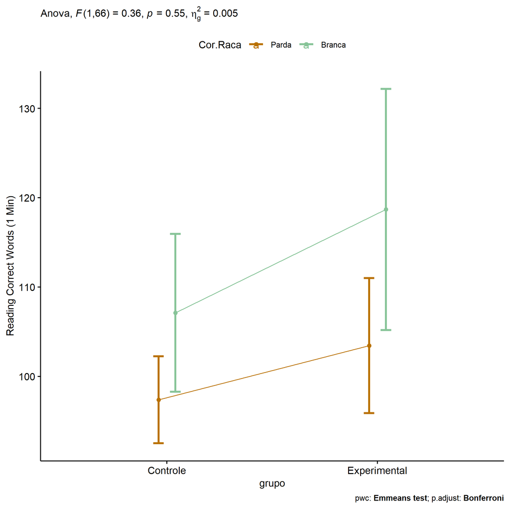

```r
if (length(unique(pdat[["Cor.Raca"]])) >= 2) {
  ggPlotAoC2(pwcs, "grupo", "Cor.Raca", aov, ylab = "Reading Correct Words (1 Min)",
             subtitle = which(aov$Effect == "grupo:Cor.Raca"), addParam = "errorbar") +
    ggplot2::scale_color_manual(values = color[["Cor.Raca"]]) +
    if (ymin.ci < ymax.ci) ggplot2::ylim(ymin.ci, ymax.ci)
}
```

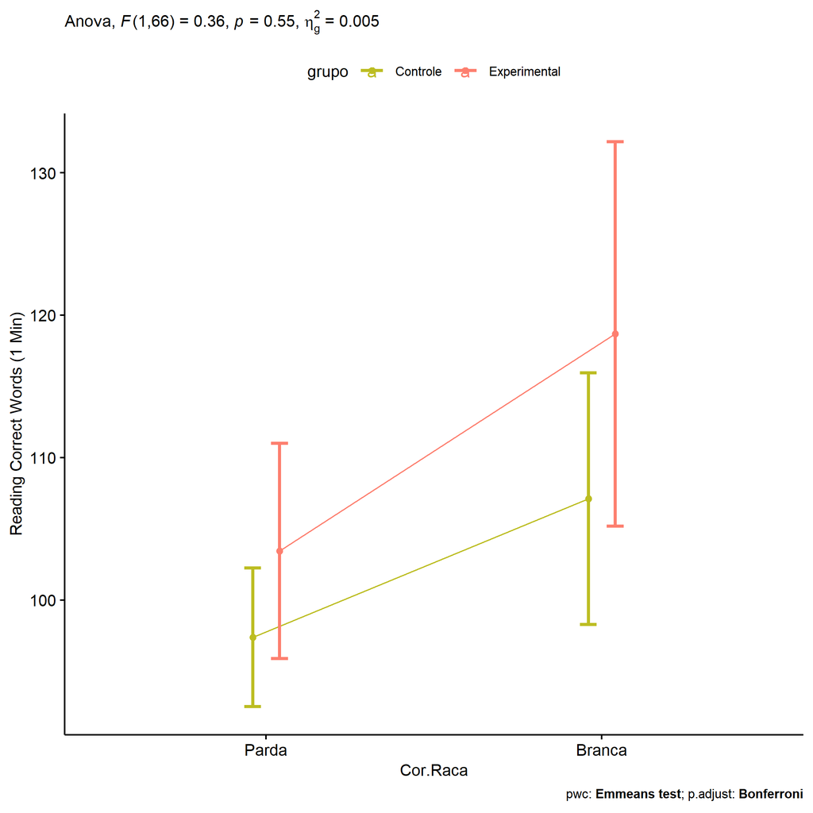

```r
if (length(unique(pdat[["Cor.Raca"]])) >= 2) {
  ggPlotAoC2(pwcs, "Cor.Raca", "grupo", aov, ylab = "Reading Correct Words (1 Min)",
               subtitle = which(aov$Effect == "grupo:Cor.Raca"), addParam = "errorbar") +
      ggplot2::scale_color_manual(values = color[["grupo"]]) +
      if (ymin.ci < ymax.ci) ggplot2::ylim(ymin.ci, ymax.ci)
}
```

```r
if (length(unique(pdat[["Cor.Raca"]])) >= 2) {
  plots <- twoWayAncovaBoxPlots(
    wdat, "TFL.corretas.per.min.pos", c("grupo","Cor.Raca"), aov, pwcs, covar = "TFL.corretas.per.min.pre",
    theme = "classic", color = color[["grupo:Cor.Raca"]],
    subtitle = which(aov$Effect == "grupo:Cor.Raca"))
}
```

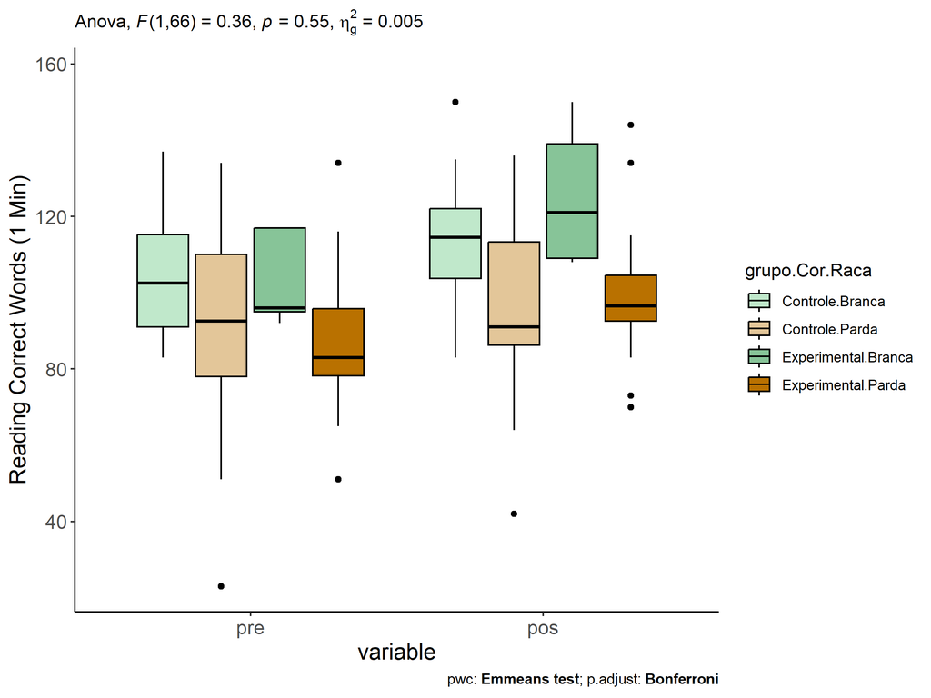

```r
if (length(unique(pdat[["Cor.Raca"]])) >= 2) {
  plots[["grupo:Cor.Raca"]] + ggplot2::ylab("Reading Correct Words (1 Min)") +
  ggplot2::scale_x_discrete(labels=c('pre', 'pos')) +
  if (ymin < ymax) ggplot2::ylim(ymin, ymax)
}
```

```r
if (length(unique(pdat[["Cor.Raca"]])) >= 2) {
  plots <- twoWayAncovaBoxPlots(
    wdat.long, "TFL.corretas.per.min", c("grupo","Cor.Raca"), aov, pwc.long,
    pre.post = "time",
    theme = "classic", color = color$prepost)
}
```

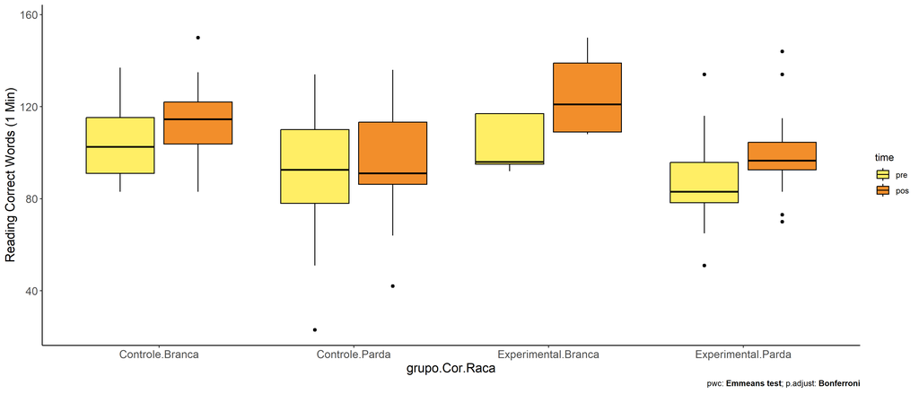

```r
if (length(unique(pdat[["Cor.Raca"]])) >= 2)
  plots[["grupo:Cor.Raca"]] + ggplot2::ylab("Reading Correct Words (1 Min)") +
    if (ymin < ymax) ggplot2::ylim(ymin, ymax)
```

### Checking linearity assumption

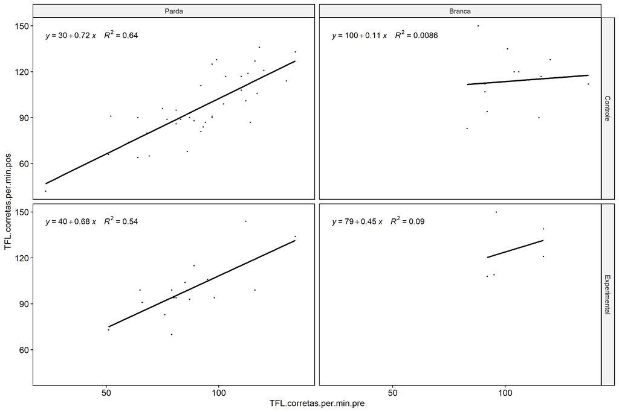

```r
if (length(unique(pdat[["Cor.Raca"]])) >= 2) {
  ggscatter(wdat, x = "TFL.corretas.per.min.pre", y = "TFL.corretas.per.min.pos", size = 0.5,
            facet.by = c("grupo","Cor.Raca"), add = "reg.line")+
    stat_regline_equation(
      aes(label =  paste(..eq.label.., ..rr.label.., sep = "~~~~"))
    ) +
    if (ymin < ymax) ggplot2::ylim(ymin, ymax)
}
```

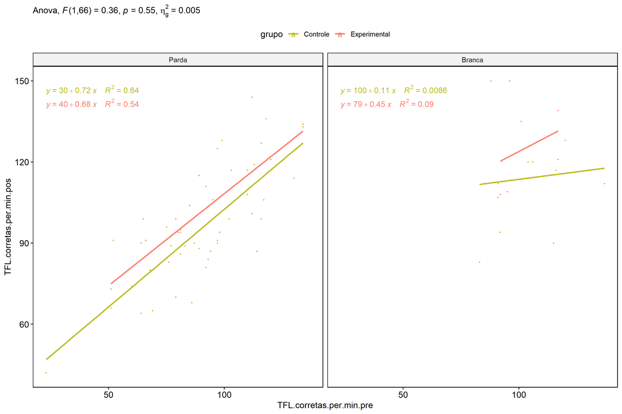

```r
if (length(unique(pdat[["Cor.Raca"]])) >= 2) {
  ggscatter(wdat, x = "TFL.corretas.per.min.pre", y = "TFL.corretas.per.min.pos", size = 0.5,
            color = "grupo", facet.by = "Cor.Raca", add = "reg.line")+
    stat_regline_equation(
      aes(label =  paste(..eq.label.., ..rr.label.., sep = "~~~~"), color = grupo)
    ) +
    ggplot2::labs(subtitle = rstatix::get_test_label(aov, detailed = T, row = which(aov$Effect == "grupo:Cor.Raca"))) +
    ggplot2::scale_color_manual(values = color[["grupo"]]) +
    if (ymin < ymax) ggplot2::ylim(ymin, ymax)
}
```

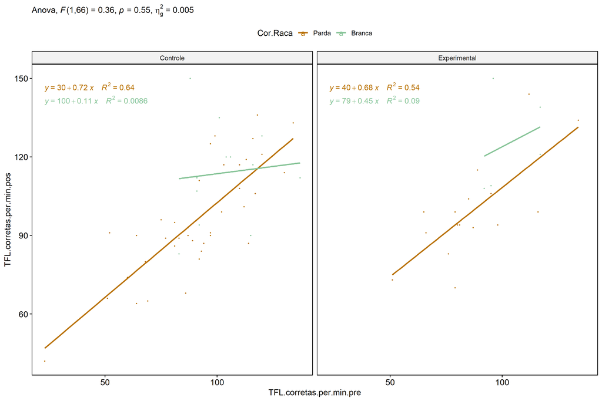

```r
if (length(unique(pdat[["Cor.Raca"]])) >= 2) {
  ggscatter(wdat, x = "TFL.corretas.per.min.pre", y = "TFL.corretas.per.min.pos", size = 0.5,
            color = "Cor.Raca", facet.by = "grupo", add = "reg.line")+
    stat_regline_equation(
      aes(label =  paste(..eq.label.., ..rr.label.., sep = "~~~~"), color = Cor.Raca)
    ) +
    ggplot2::labs(subtitle = rstatix::get_test_label(aov, detailed = T, row = which(aov$Effect == "grupo:Cor.Raca"))) +
    ggplot2::scale_color_manual(values = color[["Cor.Raca"]]) +
    if (ymin < ymax) ggplot2::ylim(ymin, ymax)
}
```

### Checking normality and homogeneity

```r
if (length(unique(pdat[["Cor.Raca"]])) >= 2)
  res <- augment(lm(TFL.corretas.per.min.pos ~ TFL.corretas.per.min.pre + grupo*Cor.Raca, data = wdat))
```

```r
if (length(unique(pdat[["Cor.Raca"]])) >= 2)
  shapiro_test(res$.resid)
```

```
## # A tibble: 1 × 3
##   variable   statistic p.value
##   <chr>          <dbl>   <dbl>
## 1 res$.resid     0.982   0.383
```

```r
if (length(unique(pdat[["Cor.Raca"]])) >= 2)
  levene_test(res, .resid ~ grupo*Cor.Raca)
```

```
## # A tibble: 1 × 4
##     df1   df2 statistic     p
##   <int> <int>     <dbl> <dbl>
## 1     3    67     0.750 0.526
```

# ANCOVA and Pairwise for two factors **grupo:Serie**

## Without remove non-normal data

```r
pdat = remove_group_data(dat[!is.na(dat[["grupo"]]) & !is.na(dat[["Serie"]]),],
                         "TFL.corretas.per.min.pos", c("grupo","Serie"))
pdat = pdat[pdat[["Serie"]] %in% do.call(
  intersect, lapply(unique(pdat[["grupo"]]), FUN = function(x) {
    unique(pdat[["Serie"]][which(pdat[["grupo"]] == x)])
  })),]
pdat[["grupo"]] = factor(pdat[["grupo"]], level[["grupo"]])
pdat[["Serie"]] = factor(
  pdat[["Serie"]],
  level[["Serie"]][level[["Serie"]] %in% unique(pdat[["Serie"]])])

pdat.long <- rbind(pdat[,c("id","grupo","Serie")], pdat[,c("id","grupo","Serie")])
pdat.long[["time"]] <- c(rep("pre", nrow(pdat)), rep("pos", nrow(pdat)))
pdat.long[["time"]] <- factor(pdat.long[["time"]], c("pre","pos"))
pdat.long[["TFL.corretas.per.min"]] <- c(pdat[["TFL.corretas.per.min.pre"]], pdat[["TFL.corretas.per.min.pos"]])

if (length(unique(pdat[["Serie"]])) >= 2) {
  aov = anova_test(pdat, TFL.corretas.per.min.pos ~ TFL.corretas.per.min.pre + grupo*Serie)
  laov[["grupo:Serie"]] <- get_anova_table(aov)
}
```

```r
if (length(unique(pdat[["Serie"]])) >= 2) {
  pwcs <- list()
  pwcs[["Serie"]] <- emmeans_test(
    group_by(pdat, grupo), TFL.corretas.per.min.pos ~ Serie,
    covariate = TFL.corretas.per.min.pre, p.adjust.method = "bonferroni")
  pwcs[["grupo"]] <- emmeans_test(
    group_by(pdat, Serie), TFL.corretas.per.min.pos ~ grupo,
    covariate = TFL.corretas.per.min.pre, p.adjust.method = "bonferroni")

  pwc <- plyr::rbind.fill(pwcs[["grupo"]], pwcs[["Serie"]])
  pwc <- pwc[,c("grupo","Serie", colnames(pwc)[!colnames(pwc) %in% c("grupo","Serie")])]
}
```

```r
if (length(unique(pdat[["Serie"]])) >= 2) {
  pwc.long <- emmeans_test(dplyr::group_by_at(pdat.long, c("grupo","Serie")),
                           TFL.corretas.per.min ~ time,
                           p.adjust.method = "bonferroni")
  lpwc[["grupo:Serie"]] <- plyr::rbind.fill(pwc, pwc.long)
}
```

```r
if (length(unique(pdat[["Serie"]])) >= 2) {
  ds <- get.descriptives(pdat, "TFL.corretas.per.min.pos", c("grupo","Serie"), covar = "TFL.corretas.per.min.pre")
  ds <- merge(ds[ds$variable != "TFL.corretas.per.min.pre",],
              ds[ds$variable == "TFL.corretas.per.min.pre", !colnames(ds) %in% c("variable")],
              by = c("grupo","Serie"), all.x = T, suffixes = c("", ".TFL.corretas.per.min.pre"))
  ds <- merge(get_emmeans(pwcs[["grupo"]]), ds,
              by = c("grupo","Serie"), suffixes = c(".emms", ""))
  ds <- ds[,c("grupo","Serie","n","mean.TFL.corretas.per.min.pre","se.TFL.corretas.per.min.pre","mean","se",
              "emmean","se.emms","conf.low","conf.high")]

  colnames(ds) <- c("grupo","Serie", "N", paste0(c("M","SE")," (pre)"),
                    paste0(c("M","SE"), " (unadj)"),
                    paste0(c("M", "SE"), " (adj)"), "conf.low", "conf.high")

  lemms[["grupo:Serie"]] <- ds
}
```

## Computing ANCOVA and PairWise After removing non-normal data (OK)

```r
if (length(unique(pdat[["Serie"]])) >= 2) {
  wdat = pdat

  res = residuals(lm(TFL.corretas.per.min.pos ~ TFL.corretas.per.min.pre + grupo*Serie, data = wdat))
  non.normal = getNonNormal(res, wdat$id, plimit = 0.05)

  wdat = wdat[!wdat$id %in% non.normal,]

  wdat.long <- rbind(wdat[,c("id","grupo","Serie")], wdat[,c("id","grupo","Serie")])
  wdat.long[["time"]] <- c(rep("pre", nrow(wdat)), rep("pos", nrow(wdat)))
  wdat.long[["time"]] <- factor(wdat.long[["time"]], c("pre","pos"))
  wdat.long[["TFL.corretas.per.min"]] <- c(wdat[["TFL.corretas.per.min.pre"]], wdat[["TFL.corretas.per.min.pos"]])


  ldat[["grupo:Serie"]] = wdat

  (non.normal)
}
```

```
##   [1] "P1010" "P3609" "P956"  "P3721" "P3498" "P1109" "P808"  "P3729" "P1017" "P628"  "P621"
##  [12] "P1097" "P463"  "P820"  "P133"  "P128"  "P1716" "P994"  "P3516" "P3505" "P445"  "P3581"
##  [23] "P942"  "P3521" "P616"  "P3627" "P3615" "P3504" "P997"  "P446"  "P614"  "P1089" "P3566"
##  [34] "P947"  "P3492" "P829"  "P465"  "P184"  "P625"  "P3734" "P451"  "P3606" "P618"  "P3501"
##  [45] "P3624" "P950"  "P612"  "P2210" "P1004" "P620"  "P3558" "P1107" "P1000" "P816"  "P3512"
##  [56] "P3495" "P3509" "P3565" "P448"  "P615"  "P241"  "P3524" "P521"  "P3502" "P613"  "P1084"
##  [67] "P3518" "P812"  "P2239" "P626"  "P3598" "P936"  "P513"  "P516"  "P1742" "P143"  "P1091"
##  [78] "P459"  "P515"  "P3560" "P958"  "P512"  "P948"  "P622"  "P460"  "P457"  "P523"  "P813"
##  [89] "P943"  "P238"  "P522"  "P464"  "P449"  "P2378" "P1743" "P1768" "P3569" "P510"  "P121"
## [100] "P176"  "P3519" "P1728" "P3508" "P945"
```

```r
if (length(unique(pdat[["Serie"]])) >= 2) {
  aov = anova_test(wdat, TFL.corretas.per.min.pos ~ TFL.corretas.per.min.pre + grupo*Serie)
  laov[["grupo:Serie"]] <- merge(get_anova_table(aov), laov[["grupo:Serie"]],
                                         by="Effect", suffixes = c("","'"))
  df = get_anova_table(aov)
}
```

| Effect | DFn | DFd | F | p | p<.05 | ges |
| --- | --- | --- | --- | --- | --- | --- |
| TFL.corretas.per.min.pre | 1 | 30 | 109.483 | 0.000 | * | 0.785 |
| grupo | 1 | 30 | 1.303 | 0.263 |  | 0.042 |
| Serie | 3 | 30 | 11.753 | 0.000 | * | 0.540 |
| grupo:Serie | 3 | 30 | 7.184 | 0.001 | * | 0.418 |

```r
if (length(unique(pdat[["Serie"]])) >= 2) {
  pwcs <- list()
  pwcs[["Serie"]] <- emmeans_test(
    group_by(wdat, grupo), TFL.corretas.per.min.pos ~ Serie,
    covariate = TFL.corretas.per.min.pre, p.adjust.method = "bonferroni")
  pwcs[["grupo"]] <- emmeans_test(
    group_by(wdat, Serie), TFL.corretas.per.min.pos ~ grupo,
    covariate = TFL.corretas.per.min.pre, p.adjust.method = "bonferroni")

  pwc <- plyr::rbind.fill(pwcs[["grupo"]], pwcs[["Serie"]])
  pwc <- pwc[,c("grupo","Serie", colnames(pwc)[!colnames(pwc) %in% c("grupo","Serie")])]
}
```

| grupo | Serie | term | .y. | group1 | group2 | df | statistic | p | p.adj | p.adj.signif |
| --- | --- | --- | --- | --- | --- | --- | --- | --- | --- | --- |
|  | 6 ano | TFL.corretas.per.min.pre*grupo | TFL.corretas.per.min.pos | Controle | Experimental | 30 | -3.450 | 0.002 | 0.002 | ** |
|  | 7 ano | TFL.corretas.per.min.pre*grupo | TFL.corretas.per.min.pos | Controle | Experimental | 30 | 0.449 | 0.657 | 0.657 | ns |
|  | 8 ano | TFL.corretas.per.min.pre*grupo | TFL.corretas.per.min.pos | Controle | Experimental | 30 | 2.418 | 0.022 | 0.022 | * |
|  | 9 ano | TFL.corretas.per.min.pre*grupo | TFL.corretas.per.min.pos | Controle | Experimental | 30 | 2.386 | 0.024 | 0.024 | * |
| Controle |  | TFL.corretas.per.min.pre*Serie | TFL.corretas.per.min.pos | 6 ano | 7 ano | 30 | 1.244 | 0.223 | 1.000 | ns |
| Controle |  | TFL.corretas.per.min.pre*Serie | TFL.corretas.per.min.pos | 6 ano | 8 ano | 30 | -4.332 | 0.000 | 0.001 | *** |
| Controle |  | TFL.corretas.per.min.pre*Serie | TFL.corretas.per.min.pos | 6 ano | 9 ano | 30 | -4.191 | 0.000 | 0.001 | ** |
| Controle |  | TFL.corretas.per.min.pre*Serie | TFL.corretas.per.min.pos | 7 ano | 8 ano | 30 | -4.090 | 0.000 | 0.002 | ** |
| Controle |  | TFL.corretas.per.min.pre*Serie | TFL.corretas.per.min.pos | 7 ano | 9 ano | 30 | -3.938 | 0.000 | 0.003 | ** |
| Controle |  | TFL.corretas.per.min.pre*Serie | TFL.corretas.per.min.pos | 8 ano | 9 ano | 30 | 0.369 | 0.714 | 1.000 | ns |
| Experimental |  | TFL.corretas.per.min.pre*Serie | TFL.corretas.per.min.pos | 6 ano | 7 ano | 30 | 4.539 | 0.000 | 0.001 | *** |
| Experimental |  | TFL.corretas.per.min.pre*Serie | TFL.corretas.per.min.pos | 6 ano | 8 ano | 30 | 2.319 | 0.027 | 0.164 | ns |
| Experimental |  | TFL.corretas.per.min.pre*Serie | TFL.corretas.per.min.pos | 6 ano | 9 ano | 30 | 2.477 | 0.019 | 0.115 | ns |
| Experimental |  | TFL.corretas.per.min.pre*Serie | TFL.corretas.per.min.pos | 7 ano | 8 ano | 30 | -2.805 | 0.009 | 0.052 | ns |
| Experimental |  | TFL.corretas.per.min.pre*Serie | TFL.corretas.per.min.pos | 7 ano | 9 ano | 30 | -2.306 | 0.028 | 0.169 | ns |
| Experimental |  | TFL.corretas.per.min.pre*Serie | TFL.corretas.per.min.pos | 8 ano | 9 ano | 30 | 0.339 | 0.737 | 1.000 | ns |

```r
if (length(unique(pdat[["Serie"]])) >= 2) {
  pwc.long <- emmeans_test(dplyr::group_by_at(wdat.long, c("grupo","Serie")),
                           TFL.corretas.per.min ~ time,
                           p.adjust.method = "bonferroni")
  lpwc[["grupo:Serie"]] <- merge(plyr::rbind.fill(pwc, pwc.long),
                                         lpwc[["grupo:Serie"]],
                                         by=c("grupo","Serie","term",".y.","group1","group2"),
                                         suffixes = c("","'"))
}
```

| grupo | Serie | term | .y. | group1 | group2 | df | statistic | p | p.adj | p.adj.signif |
| --- | --- | --- | --- | --- | --- | --- | --- | --- | --- | --- |
| Controle | 6 ano | time | TFL.corretas.per.min | pre | pos | 62 | -3.569 | 0.001 | 0.001 | *** |
| Controle | 7 ano | time | TFL.corretas.per.min | pre | pos | 62 | -1.634 | 0.107 | 0.107 | ns |
| Controle | 8 ano | time | TFL.corretas.per.min | pre | pos | 62 | -5.635 | 0.000 | 0.000 | **** |
| Controle | 9 ano | time | TFL.corretas.per.min | pre | pos | 62 | -6.046 | 0.000 | 0.000 | **** |
| Experimental | 6 ano | time | TFL.corretas.per.min | pre | pos | 62 | -3.078 | 0.003 | 0.003 | ** |
| Experimental | 7 ano | time | TFL.corretas.per.min | pre | pos | 62 | -1.373 | 0.175 | 0.175 | ns |
| Experimental | 8 ano | time | TFL.corretas.per.min | pre | pos | 62 | -2.729 | 0.008 | 0.008 | ** |
| Experimental | 9 ano | time | TFL.corretas.per.min | pre | pos | 62 | -2.204 | 0.031 | 0.031 | * |

```r
if (length(unique(pdat[["Serie"]])) >= 2) {
  ds <- get.descriptives(wdat, "TFL.corretas.per.min.pos", c("grupo","Serie"), covar = "TFL.corretas.per.min.pre")
  ds <- merge(ds[ds$variable != "TFL.corretas.per.min.pre",],
              ds[ds$variable == "TFL.corretas.per.min.pre", !colnames(ds) %in% c("variable")],
              by = c("grupo","Serie"), all.x = T, suffixes = c("", ".TFL.corretas.per.min.pre"))
  ds <- merge(get_emmeans(pwcs[["grupo"]]), ds,
              by = c("grupo","Serie"), suffixes = c(".emms", ""))
  ds <- ds[,c("grupo","Serie","n","mean.TFL.corretas.per.min.pre","se.TFL.corretas.per.min.pre",
              "mean","se","emmean","se.emms","conf.low","conf.high")]

  colnames(ds) <- c("grupo","Serie", "N", paste0(c("M","SE")," (pre)"),
                    paste0(c("M","SE"), " (unadj)"),
                    paste0(c("M", "SE"), " (adj)"), "conf.low", "conf.high")

  lemms[["grupo:Serie"]] <- merge(ds, lemms[["grupo:Serie"]],
                                          by=c("grupo","Serie"), suffixes = c("","'"))
}
```

| grupo | Serie | N | M (pre) | SE (pre) | M (unadj) | SE (unadj) | M (adj) | SE (adj) | conf.low | conf.high |
| --- | --- | --- | --- | --- | --- | --- | --- | --- | --- | --- |
| Controle | 6 ano | 7 | 85.429 | 12.656 | 125.714 | 8.662 | 128.623 | 3.234 | 122.018 | 135.228 |
| Controle | 7 ano | 2 | 77.000 | 20.000 | 111.500 | 13.500 | 120.090 | 6.084 | 107.666 | 132.515 |
| Controle | 8 ano | 8 | 85.125 | 8.649 | 144.625 | 6.732 | 147.738 | 3.029 | 141.553 | 153.924 |
| Controle | 9 ano | 10 | 87.900 | 6.747 | 145.000 | 5.615 | 146.243 | 2.698 | 140.732 | 151.754 |
| Experimental | 6 ano | 2 | 82.000 | 14.000 | 147.000 | 3.000 | 152.220 | 6.049 | 139.867 | 164.573 |
| Experimental | 7 ano | 3 | 99.333 | 8.950 | 123.000 | 8.021 | 116.536 | 4.961 | 106.405 | 126.666 |
| Experimental | 8 ano | 4 | 103.000 | 6.403 | 143.750 | 7.962 | 134.814 | 4.347 | 125.936 | 143.692 |
| Experimental | 9 ano | 3 | 104.667 | 7.446 | 142.667 | 3.667 | 132.607 | 5.015 | 122.365 | 142.849 |

### Plots for ancova

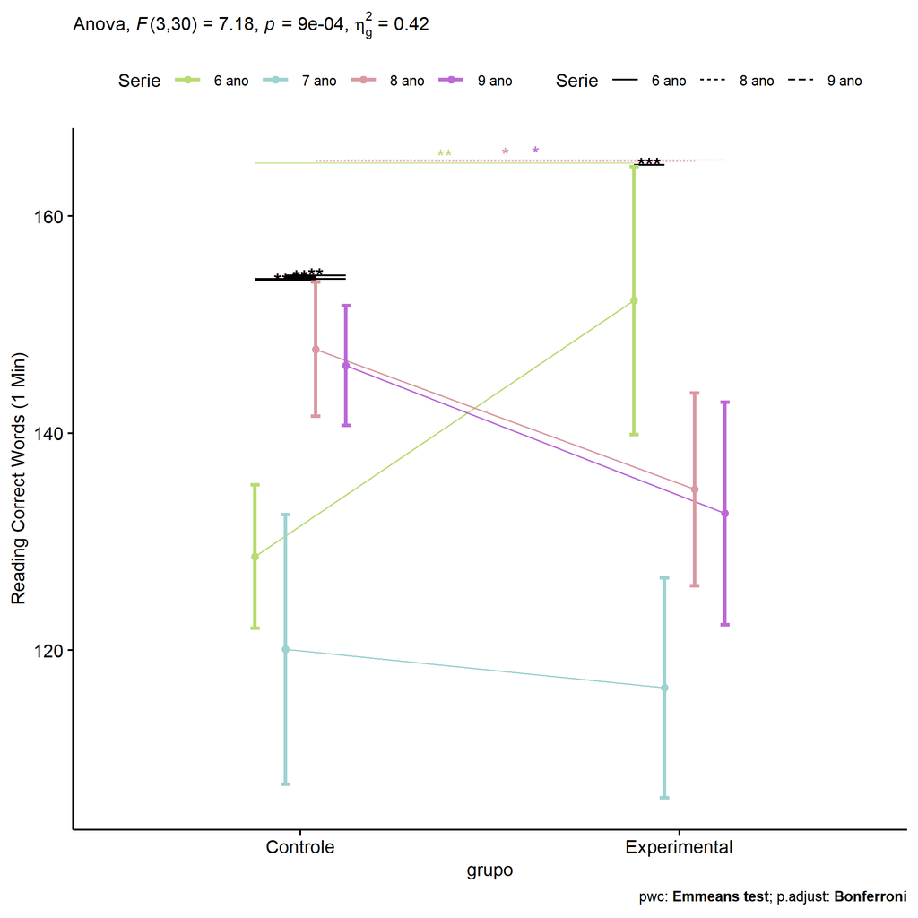

```r
if (length(unique(pdat[["Serie"]])) >= 2) {
  ggPlotAoC2(pwcs, "grupo", "Serie", aov, ylab = "Reading Correct Words (1 Min)",
             subtitle = which(aov$Effect == "grupo:Serie"), addParam = "errorbar") +
    ggplot2::scale_color_manual(values = color[["Serie"]]) +
    if (ymin.ci < ymax.ci) ggplot2::ylim(ymin.ci, ymax.ci)
}
```

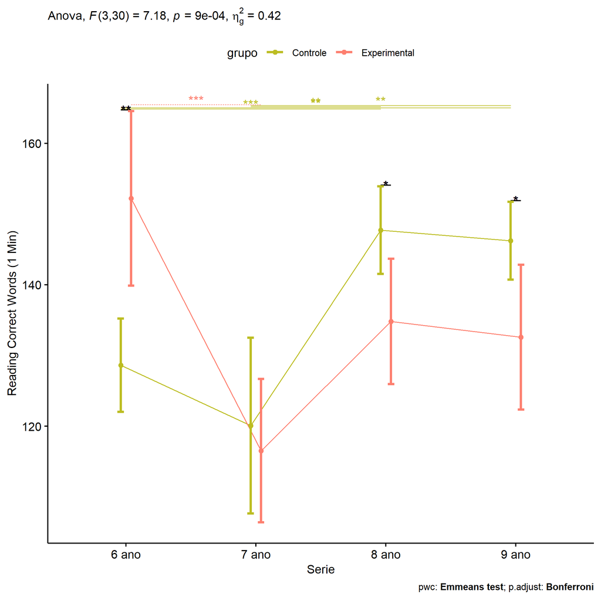

```r
if (length(unique(pdat[["Serie"]])) >= 2) {
  ggPlotAoC2(pwcs, "Serie", "grupo", aov, ylab = "Reading Correct Words (1 Min)",
               subtitle = which(aov$Effect == "grupo:Serie"), addParam = "errorbar") +
      ggplot2::scale_color_manual(values = color[["grupo"]]) +
      if (ymin.ci < ymax.ci) ggplot2::ylim(ymin.ci, ymax.ci)
}
```

```r
if (length(unique(pdat[["Serie"]])) >= 2) {
  plots <- twoWayAncovaBoxPlots(
    wdat, "TFL.corretas.per.min.pos", c("grupo","Serie"), aov, pwcs, covar = "TFL.corretas.per.min.pre",
    theme = "classic", color = color[["grupo:Serie"]],
    subtitle = which(aov$Effect == "grupo:Serie"))
}
```

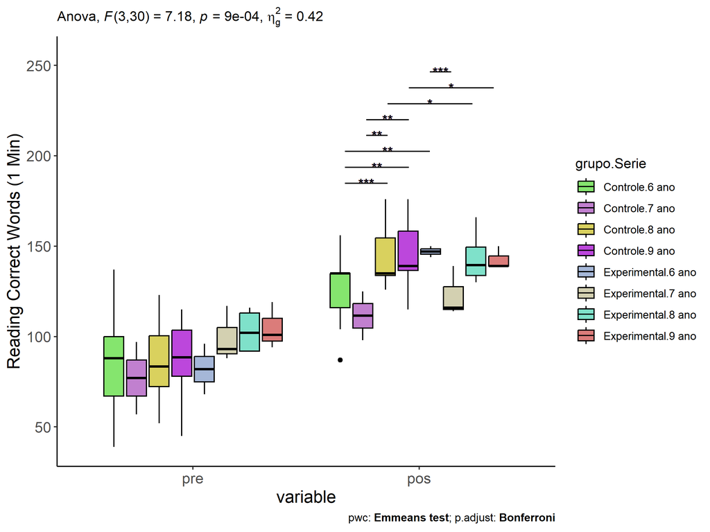

```r
if (length(unique(pdat[["Serie"]])) >= 2) {
  plots[["grupo:Serie"]] + ggplot2::ylab("Reading Correct Words (1 Min)") +
  ggplot2::scale_x_discrete(labels=c('pre', 'pos')) +
  if (ymin < ymax) ggplot2::ylim(ymin, ymax)
}
```

```r
if (length(unique(pdat[["Serie"]])) >= 2) {
  plots <- twoWayAncovaBoxPlots(
    wdat.long, "TFL.corretas.per.min", c("grupo","Serie"), aov, pwc.long,
    pre.post = "time",
    theme = "classic", color = color$prepost)
}
```

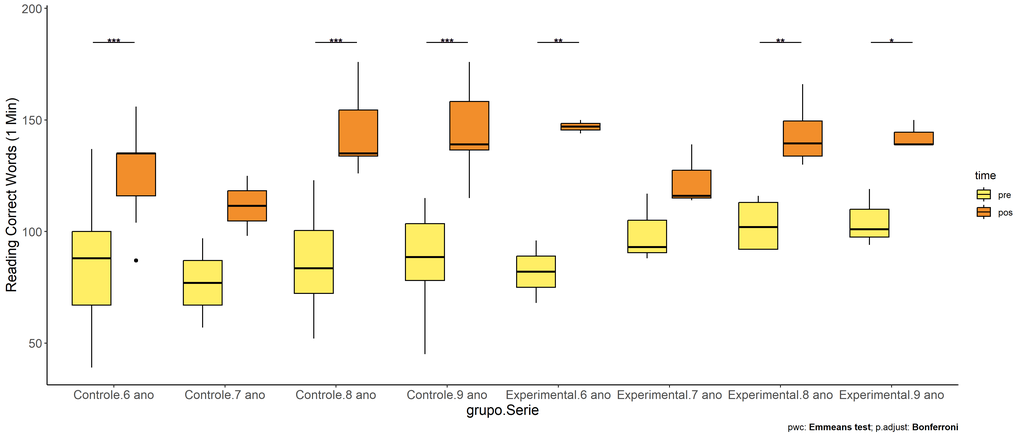

```r
if (length(unique(pdat[["Serie"]])) >= 2)
  plots[["grupo:Serie"]] + ggplot2::ylab("Reading Correct Words (1 Min)") +
    if (ymin < ymax) ggplot2::ylim(ymin, ymax)
```

### Checking linearity assumption

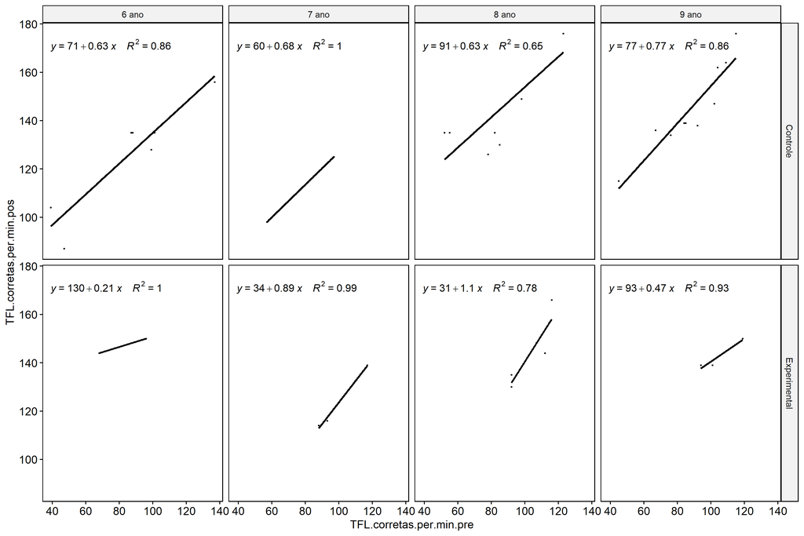

```r
if (length(unique(pdat[["Serie"]])) >= 2) {
  ggscatter(wdat, x = "TFL.corretas.per.min.pre", y = "TFL.corretas.per.min.pos", size = 0.5,
            facet.by = c("grupo","Serie"), add = "reg.line")+
    stat_regline_equation(
      aes(label =  paste(..eq.label.., ..rr.label.., sep = "~~~~"))
    ) +
    if (ymin < ymax) ggplot2::ylim(ymin, ymax)
}
```

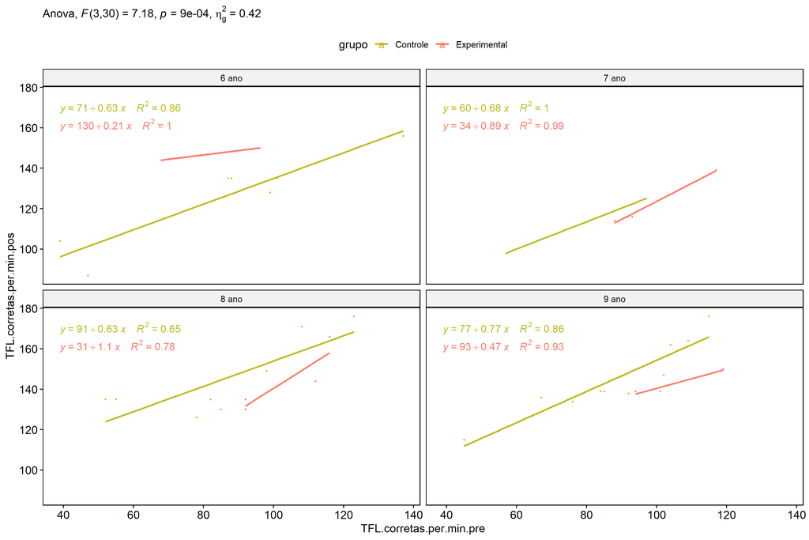

```r
if (length(unique(pdat[["Serie"]])) >= 2) {
  ggscatter(wdat, x = "TFL.corretas.per.min.pre", y = "TFL.corretas.per.min.pos", size = 0.5,
            color = "grupo", facet.by = "Serie", add = "reg.line")+
    stat_regline_equation(
      aes(label =  paste(..eq.label.., ..rr.label.., sep = "~~~~"), color = grupo)
    ) +
    ggplot2::labs(subtitle = rstatix::get_test_label(aov, detailed = T, row = which(aov$Effect == "grupo:Serie"))) +
    ggplot2::scale_color_manual(values = color[["grupo"]]) +
    if (ymin < ymax) ggplot2::ylim(ymin, ymax)
}
```

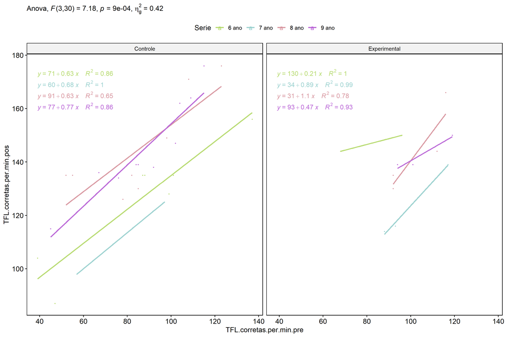

```r
if (length(unique(pdat[["Serie"]])) >= 2) {
  ggscatter(wdat, x = "TFL.corretas.per.min.pre", y = "TFL.corretas.per.min.pos", size = 0.5,
            color = "Serie", facet.by = "grupo", add = "reg.line")+
    stat_regline_equation(
      aes(label =  paste(..eq.label.., ..rr.label.., sep = "~~~~"), color = Serie)
    ) +
    ggplot2::labs(subtitle = rstatix::get_test_label(aov, detailed = T, row = which(aov$Effect == "grupo:Serie"))) +
    ggplot2::scale_color_manual(values = color[["Serie"]]) +
    if (ymin < ymax) ggplot2::ylim(ymin, ymax)
}
```

### Checking normality and homogeneity

```r
if (length(unique(pdat[["Serie"]])) >= 2)
  res <- augment(lm(TFL.corretas.per.min.pos ~ TFL.corretas.per.min.pre + grupo*Serie, data = wdat))
```

```r
if (length(unique(pdat[["Serie"]])) >= 2)
  shapiro_test(res$.resid)
```

```
## # A tibble: 1 × 3
##   variable   statistic p.value
##   <chr>          <dbl>   <dbl>
## 1 res$.resid     0.967   0.309
```

```r
if (length(unique(pdat[["Serie"]])) >= 2)
  levene_test(res, .resid ~ grupo*Serie)
```

```
## # A tibble: 1 × 4
##     df1   df2 statistic      p
##   <int> <int>     <dbl>  <dbl>
## 1     7    31      2.34 0.0489
```

# ANCOVA and Pairwise for two factors **grupo:TFL.corretas.per.min.quintile**

## Without remove non-normal data

```r
pdat = remove_group_data(dat[!is.na(dat[["grupo"]]) & !is.na(dat[["TFL.corretas.per.min.quintile"]]),],
                         "TFL.corretas.per.min.pos", c("grupo","TFL.corretas.per.min.quintile"))
pdat = pdat[pdat[["TFL.corretas.per.min.quintile"]] %in% do.call(
  intersect, lapply(unique(pdat[["grupo"]]), FUN = function(x) {
    unique(pdat[["TFL.corretas.per.min.quintile"]][which(pdat[["grupo"]] == x)])
  })),]
pdat[["grupo"]] = factor(pdat[["grupo"]], level[["grupo"]])
pdat[["TFL.corretas.per.min.quintile"]] = factor(
  pdat[["TFL.corretas.per.min.quintile"]],
  level[["TFL.corretas.per.min.quintile"]][level[["TFL.corretas.per.min.quintile"]] %in% unique(pdat[["TFL.corretas.per.min.quintile"]])])

pdat.long <- rbind(pdat[,c("id","grupo","TFL.corretas.per.min.quintile")], pdat[,c("id","grupo","TFL.corretas.per.min.quintile")])
pdat.long[["time"]] <- c(rep("pre", nrow(pdat)), rep("pos", nrow(pdat)))
pdat.long[["time"]] <- factor(pdat.long[["time"]], c("pre","pos"))
pdat.long[["TFL.corretas.per.min"]] <- c(pdat[["TFL.corretas.per.min.pre"]], pdat[["TFL.corretas.per.min.pos"]])

if (length(unique(pdat[["TFL.corretas.per.min.quintile"]])) >= 2) {
  aov = anova_test(pdat, TFL.corretas.per.min.pos ~ TFL.corretas.per.min.pre + grupo*TFL.corretas.per.min.quintile)
  laov[["grupo:TFL.corretas.per.min.quintile"]] <- get_anova_table(aov)
}
```

```r
if (length(unique(pdat[["TFL.corretas.per.min.quintile"]])) >= 2) {
  pwcs <- list()
  pwcs[["TFL.corretas.per.min.quintile"]] <- emmeans_test(
    group_by(pdat, grupo), TFL.corretas.per.min.pos ~ TFL.corretas.per.min.quintile,
    covariate = TFL.corretas.per.min.pre, p.adjust.method = "bonferroni")
  pwcs[["grupo"]] <- emmeans_test(
    group_by(pdat, TFL.corretas.per.min.quintile), TFL.corretas.per.min.pos ~ grupo,
    covariate = TFL.corretas.per.min.pre, p.adjust.method = "bonferroni")

  pwc <- plyr::rbind.fill(pwcs[["grupo"]], pwcs[["TFL.corretas.per.min.quintile"]])
  pwc <- pwc[,c("grupo","TFL.corretas.per.min.quintile", colnames(pwc)[!colnames(pwc) %in% c("grupo","TFL.corretas.per.min.quintile")])]
}
```

```r
if (length(unique(pdat[["TFL.corretas.per.min.quintile"]])) >= 2) {
  pwc.long <- emmeans_test(dplyr::group_by_at(pdat.long, c("grupo","TFL.corretas.per.min.quintile")),
                           TFL.corretas.per.min ~ time,
                           p.adjust.method = "bonferroni")
  lpwc[["grupo:TFL.corretas.per.min.quintile"]] <- plyr::rbind.fill(pwc, pwc.long)
}
```

```r
if (length(unique(pdat[["TFL.corretas.per.min.quintile"]])) >= 2) {
  ds <- get.descriptives(pdat, "TFL.corretas.per.min.pos", c("grupo","TFL.corretas.per.min.quintile"), covar = "TFL.corretas.per.min.pre")
  ds <- merge(ds[ds$variable != "TFL.corretas.per.min.pre",],
              ds[ds$variable == "TFL.corretas.per.min.pre", !colnames(ds) %in% c("variable")],
              by = c("grupo","TFL.corretas.per.min.quintile"), all.x = T, suffixes = c("", ".TFL.corretas.per.min.pre"))
  ds <- merge(get_emmeans(pwcs[["grupo"]]), ds,
              by = c("grupo","TFL.corretas.per.min.quintile"), suffixes = c(".emms", ""))
  ds <- ds[,c("grupo","TFL.corretas.per.min.quintile","n","mean.TFL.corretas.per.min.pre","se.TFL.corretas.per.min.pre","mean","se",
              "emmean","se.emms","conf.low","conf.high")]

  colnames(ds) <- c("grupo","TFL.corretas.per.min.quintile", "N", paste0(c("M","SE")," (pre)"),
                    paste0(c("M","SE"), " (unadj)"),
                    paste0(c("M", "SE"), " (adj)"), "conf.low", "conf.high")

  lemms[["grupo:TFL.corretas.per.min.quintile"]] <- ds
}
```

## Computing ANCOVA and PairWise After removing non-normal data (OK)

```r
if (length(unique(pdat[["TFL.corretas.per.min.quintile"]])) >= 2) {
  wdat = pdat

  res = residuals(lm(TFL.corretas.per.min.pos ~ TFL.corretas.per.min.pre + grupo*TFL.corretas.per.min.quintile, data = wdat))
  non.normal = getNonNormal(res, wdat$id, plimit = 0.05)

  wdat = wdat[!wdat$id %in% non.normal,]

  wdat.long <- rbind(wdat[,c("id","grupo","TFL.corretas.per.min.quintile")], wdat[,c("id","grupo","TFL.corretas.per.min.quintile")])
  wdat.long[["time"]] <- c(rep("pre", nrow(wdat)), rep("pos", nrow(wdat)))
  wdat.long[["time"]] <- factor(wdat.long[["time"]], c("pre","pos"))
  wdat.long[["TFL.corretas.per.min"]] <- c(wdat[["TFL.corretas.per.min.pre"]], wdat[["TFL.corretas.per.min.pos"]])


  ldat[["grupo:TFL.corretas.per.min.quintile"]] = wdat

  (non.normal)
}
```

```
##  [1] "P3516" "P2378" "P1010" "P1768" "P2294" "P2250" "P510"  "P1698" "P808"  "P1743" "P121"
## [12] "P2408" "P2404" "P2240" "P2380" "P2385" "P2211" "P2376" "P1699" "P2390" "P1762" "P2377"
## [23] "P2214" "P2220" "P2209" "P1713" "P2247" "P2244" "P945"  "P463"  "P623"  "P2222" "P2401"
## [34] "P2383" "P2249"
```

```r
if (length(unique(pdat[["TFL.corretas.per.min.quintile"]])) >= 2) {
  aov = anova_test(wdat, TFL.corretas.per.min.pos ~ TFL.corretas.per.min.pre + grupo*TFL.corretas.per.min.quintile)
  laov[["grupo:TFL.corretas.per.min.quintile"]] <- merge(get_anova_table(aov), laov[["grupo:TFL.corretas.per.min.quintile"]],
                                         by="Effect", suffixes = c("","'"))
  df = get_anova_table(aov)
}
```

| Effect | DFn | DFd | F | p | p<.05 | ges |
| --- | --- | --- | --- | --- | --- | --- |
| TFL.corretas.per.min.pre | 1 | 97 | 18.514 | 0.000 | * | 0.160 |
| grupo | 1 | 97 | 3.717 | 0.057 |  | 0.037 |
| TFL.corretas.per.min.quintile | 4 | 97 | 4.324 | 0.003 | * | 0.151 |
| grupo:TFL.corretas.per.min.quintile | 4 | 97 | 3.059 | 0.020 | * | 0.112 |

```r
if (length(unique(pdat[["TFL.corretas.per.min.quintile"]])) >= 2) {
  pwcs <- list()
  pwcs[["TFL.corretas.per.min.quintile"]] <- emmeans_test(
    group_by(wdat, grupo), TFL.corretas.per.min.pos ~ TFL.corretas.per.min.quintile,
    covariate = TFL.corretas.per.min.pre, p.adjust.method = "bonferroni")
  pwcs[["grupo"]] <- emmeans_test(
    group_by(wdat, TFL.corretas.per.min.quintile), TFL.corretas.per.min.pos ~ grupo,
    covariate = TFL.corretas.per.min.pre, p.adjust.method = "bonferroni")

  pwc <- plyr::rbind.fill(pwcs[["grupo"]], pwcs[["TFL.corretas.per.min.quintile"]])
  pwc <- pwc[,c("grupo","TFL.corretas.per.min.quintile", colnames(pwc)[!colnames(pwc) %in% c("grupo","TFL.corretas.per.min.quintile")])]
}
```

| grupo | TFL.corretas.per.min.quintile | term | .y. | group1 | group2 | df | statistic | p | p.adj | p.adj.signif |
| --- | --- | --- | --- | --- | --- | --- | --- | --- | --- | --- |
|  | 1st quintile | TFL.corretas.per.min.pre*grupo | TFL.corretas.per.min.pos | Controle | Experimental | 97 | 0.582 | 0.562 | 0.562 | ns |
|  | 2nd quintile | TFL.corretas.per.min.pre*grupo | TFL.corretas.per.min.pos | Controle | Experimental | 97 | 0.159 | 0.874 | 0.874 | ns |
|  | 3rd quintile | TFL.corretas.per.min.pre*grupo | TFL.corretas.per.min.pos | Controle | Experimental | 97 | -2.721 | 0.008 | 0.008 | ** |
|  | 4th quintile | TFL.corretas.per.min.pre*grupo | TFL.corretas.per.min.pos | Controle | Experimental | 97 | 0.888 | 0.377 | 0.377 | ns |
|  | 5th quintile | TFL.corretas.per.min.pre*grupo | TFL.corretas.per.min.pos | Controle | Experimental | 97 | -2.732 | 0.007 | 0.007 | ** |
| Controle |  | TFL.corretas.per.min.pre*TFL.corretas.per.min.quintile | TFL.corretas.per.min.pos | 1st quintile | 2nd quintile | 97 | 2.281 | 0.025 | 0.247 | ns |
| Controle |  | TFL.corretas.per.min.pre*TFL.corretas.per.min.quintile | TFL.corretas.per.min.pos | 1st quintile | 3rd quintile | 97 | 2.168 | 0.033 | 0.326 | ns |
| Controle |  | TFL.corretas.per.min.pre*TFL.corretas.per.min.quintile | TFL.corretas.per.min.pos | 1st quintile | 4th quintile | 97 | 0.469 | 0.640 | 1.000 | ns |
| Controle |  | TFL.corretas.per.min.pre*TFL.corretas.per.min.quintile | TFL.corretas.per.min.pos | 1st quintile | 5th quintile | 97 | 1.207 | 0.231 | 1.000 | ns |
| Controle |  | TFL.corretas.per.min.pre*TFL.corretas.per.min.quintile | TFL.corretas.per.min.pos | 2nd quintile | 3rd quintile | 97 | 0.517 | 0.606 | 1.000 | ns |
| Controle |  | TFL.corretas.per.min.pre*TFL.corretas.per.min.quintile | TFL.corretas.per.min.pos | 2nd quintile | 4th quintile | 97 | -1.769 | 0.080 | 0.801 | ns |
| Controle |  | TFL.corretas.per.min.pre*TFL.corretas.per.min.quintile | TFL.corretas.per.min.pos | 2nd quintile | 5th quintile | 97 | 0.057 | 0.954 | 1.000 | ns |
| Controle |  | TFL.corretas.per.min.pre*TFL.corretas.per.min.quintile | TFL.corretas.per.min.pos | 3rd quintile | 4th quintile | 97 | -2.781 | 0.007 | 0.065 | ns |
| Controle |  | TFL.corretas.per.min.pre*TFL.corretas.per.min.quintile | TFL.corretas.per.min.pos | 3rd quintile | 5th quintile | 97 | -0.318 | 0.751 | 1.000 | ns |
| Controle |  | TFL.corretas.per.min.pre*TFL.corretas.per.min.quintile | TFL.corretas.per.min.pos | 4th quintile | 5th quintile | 97 | 2.000 | 0.048 | 0.483 | ns |
| Experimental |  | TFL.corretas.per.min.pre*TFL.corretas.per.min.quintile | TFL.corretas.per.min.pos | 1st quintile | 2nd quintile | 97 | 1.709 | 0.091 | 0.907 | ns |
| Experimental |  | TFL.corretas.per.min.pre*TFL.corretas.per.min.quintile | TFL.corretas.per.min.pos | 1st quintile | 3rd quintile | 97 | 0.152 | 0.879 | 1.000 | ns |
| Experimental |  | TFL.corretas.per.min.pre*TFL.corretas.per.min.quintile | TFL.corretas.per.min.pos | 1st quintile | 4th quintile | 97 | 0.553 | 0.581 | 1.000 | ns |
| Experimental |  | TFL.corretas.per.min.pre*TFL.corretas.per.min.quintile | TFL.corretas.per.min.pos | 1st quintile | 5th quintile | 97 | -0.153 | 0.879 | 1.000 | ns |
| Experimental |  | TFL.corretas.per.min.pre*TFL.corretas.per.min.quintile | TFL.corretas.per.min.pos | 2nd quintile | 3rd quintile | 97 | -2.059 | 0.042 | 0.422 | ns |
| Experimental |  | TFL.corretas.per.min.pre*TFL.corretas.per.min.quintile | TFL.corretas.per.min.pos | 2nd quintile | 4th quintile | 97 | -0.998 | 0.321 | 1.000 | ns |
| Experimental |  | TFL.corretas.per.min.pre*TFL.corretas.per.min.quintile | TFL.corretas.per.min.pos | 2nd quintile | 5th quintile | 97 | -1.617 | 0.109 | 1.000 | ns |
| Experimental |  | TFL.corretas.per.min.pre*TFL.corretas.per.min.quintile | TFL.corretas.per.min.pos | 3rd quintile | 4th quintile | 97 | 0.729 | 0.468 | 1.000 | ns |
| Experimental |  | TFL.corretas.per.min.pre*TFL.corretas.per.min.quintile | TFL.corretas.per.min.pos | 3rd quintile | 5th quintile | 97 | -0.443 | 0.659 | 1.000 | ns |
| Experimental |  | TFL.corretas.per.min.pre*TFL.corretas.per.min.quintile | TFL.corretas.per.min.pos | 4th quintile | 5th quintile | 97 | -1.086 | 0.280 | 1.000 | ns |

```r
if (length(unique(pdat[["TFL.corretas.per.min.quintile"]])) >= 2) {
  pwc.long <- emmeans_test(dplyr::group_by_at(wdat.long, c("grupo","TFL.corretas.per.min.quintile")),
                           TFL.corretas.per.min ~ time,
                           p.adjust.method = "bonferroni")
  lpwc[["grupo:TFL.corretas.per.min.quintile"]] <- merge(plyr::rbind.fill(pwc, pwc.long),
                                         lpwc[["grupo:TFL.corretas.per.min.quintile"]],
                                         by=c("grupo","TFL.corretas.per.min.quintile","term",".y.","group1","group2"),
                                         suffixes = c("","'"))
}
```

| grupo | TFL.corretas.per.min.quintile | term | .y. | group1 | group2 | df | statistic | p | p.adj | p.adj.signif |
| --- | --- | --- | --- | --- | --- | --- | --- | --- | --- | --- |
| Controle | 1st quintile | time | TFL.corretas.per.min | pre | pos | 196 | -7.042 | 0.000 | 0.000 | **** |
| Controle | 2nd quintile | time | TFL.corretas.per.min | pre | pos | 196 | -2.113 | 0.036 | 0.036 | * |
| Controle | 3rd quintile | time | TFL.corretas.per.min | pre | pos | 196 | -0.743 | 0.458 | 0.458 | ns |
| Controle | 4th quintile | time | TFL.corretas.per.min | pre | pos | 196 | -4.091 | 0.000 | 0.000 | **** |
| Controle | 5th quintile | time | TFL.corretas.per.min | pre | pos | 196 | 0.555 | 0.580 | 0.580 | ns |
| Experimental | 1st quintile | time | TFL.corretas.per.min | pre | pos | 196 | -3.888 | 0.000 | 0.000 | *** |
| Experimental | 2nd quintile | time | TFL.corretas.per.min | pre | pos | 196 | -1.805 | 0.073 | 0.073 | ns |
| Experimental | 3rd quintile | time | TFL.corretas.per.min | pre | pos | 196 | -4.084 | 0.000 | 0.000 | **** |
| Experimental | 4th quintile | time | TFL.corretas.per.min | pre | pos | 196 | -1.815 | 0.071 | 0.071 | ns |
| Experimental | 5th quintile | time | TFL.corretas.per.min | pre | pos | 196 | -2.660 | 0.008 | 0.008 | ** |

```r
if (length(unique(pdat[["TFL.corretas.per.min.quintile"]])) >= 2) {
  ds <- get.descriptives(wdat, "TFL.corretas.per.min.pos", c("grupo","TFL.corretas.per.min.quintile"), covar = "TFL.corretas.per.min.pre")
  ds <- merge(ds[ds$variable != "TFL.corretas.per.min.pre",],
              ds[ds$variable == "TFL.corretas.per.min.pre", !colnames(ds) %in% c("variable")],
              by = c("grupo","TFL.corretas.per.min.quintile"), all.x = T, suffixes = c("", ".TFL.corretas.per.min.pre"))
  ds <- merge(get_emmeans(pwcs[["grupo"]]), ds,
              by = c("grupo","TFL.corretas.per.min.quintile"), suffixes = c(".emms", ""))
  ds <- ds[,c("grupo","TFL.corretas.per.min.quintile","n","mean.TFL.corretas.per.min.pre","se.TFL.corretas.per.min.pre",
              "mean","se","emmean","se.emms","conf.low","conf.high")]

  colnames(ds) <- c("grupo","TFL.corretas.per.min.quintile", "N", paste0(c("M","SE")," (pre)"),
                    paste0(c("M","SE"), " (unadj)"),
                    paste0(c("M", "SE"), " (adj)"), "conf.low", "conf.high")

  lemms[["grupo:TFL.corretas.per.min.quintile"]] <- merge(ds, lemms[["grupo:TFL.corretas.per.min.quintile"]],
                                          by=c("grupo","TFL.corretas.per.min.quintile"), suffixes = c("","'"))
}
```

| grupo | TFL.corretas.per.min.quintile | N | M (pre) | SE (pre) | M (unadj) | SE (unadj) | M (adj) | SE (adj) | conf.low | conf.high |
| --- | --- | --- | --- | --- | --- | --- | --- | --- | --- | --- |
| Controle | 1st quintile | 11 | 50.000 | 3.382 | 82.727 | 5.360 | 114.071 | 8.208 | 97.781 | 130.362 |
| Controle | 2nd quintile | 11 | 77.000 | 1.763 | 86.818 | 2.866 | 97.765 | 4.558 | 88.718 | 106.812 |
| Controle | 3rd quintile | 11 | 90.636 | 0.704 | 94.091 | 3.288 | 94.736 | 3.785 | 87.223 | 102.249 |
| Controle | 4th quintile | 17 | 101.588 | 1.064 | 116.882 | 3.662 | 109.254 | 3.521 | 102.265 | 116.243 |
| Controle | 5th quintile | 14 | 124.214 | 3.285 | 121.929 | 4.734 | 97.208 | 6.652 | 84.005 | 110.410 |
| Experimental | 1st quintile | 5 | 57.800 | 3.367 | 84.600 | 6.392 | 110.052 | 8.152 | 93.871 | 126.232 |
| Experimental | 2nd quintile | 10 | 77.600 | 1.360 | 86.400 | 2.876 | 96.894 | 4.657 | 87.651 | 106.136 |
| Experimental | 3rd quintile | 13 | 90.538 | 0.773 | 108.000 | 3.111 | 108.719 | 3.483 | 101.806 | 115.633 |
| Experimental | 4th quintile | 7 | 100.429 | 2.114 | 111.000 | 5.345 | 104.248 | 4.994 | 94.335 | 114.160 |
| Experimental | 5th quintile | 9 | 119.556 | 2.646 | 133.222 | 3.589 | 112.021 | 6.463 | 99.194 | 124.847 |